# Helth Insurance Cross Sell Prediction

## 1. Objetivo

Desenvolver um modelo de machine learning capaz de estimar a probabilidade de cada cliente de seguro saúde adquirir também um seguro veicular. A partir dessas probabilidades, gerar um **ranking ordenado de clientes por propensão de compra**, permitindo priorizar aqueles com maior chance de conversão e, assim, otimizar a estratégia de *cross-sell* e o uso dos recursos de marketing.

## 2. Sumário Executivo

Este projeto desenvolveu um **modelo de machine learning para prever a probabilidade de clientes de seguro saúde adquirirem também um seguro veicular**, com o objetivo de **priorizar contatos comerciais** e maximizar o retorno das ações de *cross-sell*.

Após o treinamento e otimização, o modelo alcançou **forte desempenho preditivo**, com:

- **AUC-ROC:** 0.858
- **AUC-PR:** 0.368
- **F1-score otimizado:** 0.4609
- **Recall da classe positiva:** 76%
- **Precision moderada:** 33%

O grande diferencial está no uso do modelo para **ranquear os clientes por probabilidade de compra**, permitindo que a empresa foque esforços apenas nos segmentos mais promissores.

Ao selecionar **apenas os 20% mais propensos**, o impacto financeiro é expressivo:

- **Lucro sem modelo:** R$ 762.200
- **Lucro com modelo:** R$ 2.025.417
- **Ganho adicional:** R$ 1.263.217
- **ROI vs aleatório:** +165,7%
- **Retorno multiplicado por:** 2,65×

Esses resultados evidenciam que o modelo **transforma a campanha**, deixando de ser uma abordagem baseada em volume e passando a ser guiada por **inteligência preditiva**. Mesmo com uma precisão moderada, comum em problemas desse tipo. O modelo é capaz de **recuperar a maior parte dos compradores** e direcionar o orçamento comercial de forma muito mais eficiente.

Em síntese, o modelo:

- Reduz desperdícios operacionais
- Aumenta significativamente a conversão
- Gera mais de **R$ 1,26 milhão** em lucro adicional
- Torna o processo de *cross-sell* **mais estratégico e altamente rentável**

Este resultado demonstra o poder da aplicação de machine learning em decisões de negócio e comprova como modelos de propensão podem se tornar **alavancas diretas de geração de valor**.

## 3. Sobre os Dados

Os dados refletem um cenário realista do mercado de seguros: muitos clientes, poucos compradores e a necessidade de identificar quem tem maior probabilidade de aceitar uma oferta adicional. Trata-se de um conjunto **desbalanceado**, no qual a maior parte dos clientes não compra o produto.

## 4. Iniciando

### 4.1 Importação das Bibliotecas

```python
import pandas as pd
import matplotlib.pyplot as plt
import seaborn as sns
import numpy as np
from scipy.stats import chi2_contingency
from sklearn.preprocessing import StandardScaler, OneHotEncoder, MinMaxScaler
from sklearn.model_selection import train_test_split, StratifiedKFold
from imblearn.ensemble import BalancedRandomForestClassifier
from sklearn.neighbors import KNeighborsClassifier
import scikitplot as skplt
from sklearn.linear_model import LogisticRegression
import xgboost as xgb
from catboost import CatBoostClassifier
from lightgbm import LGBMClassifier as lgb
from sklearn.model_selection import KFold
import optuna
import pickle
import shap
from sklearn.metrics import recall_score, precision_score, f1_score,roc_auc_score, average_precision_score, classification_report, confusion_matrix
import lightgbm as lgb
```

### 4.2 Importando estilo

```python
plt.style.use('../styles/personalestilo.mplstyle')
```

[output not shown]

### 4.3 Funções Adcionais

```python
def snake_case(lst):
    def convert(s):
        s = s.replace(' ', '_')
        new_s = ""
        for i, c in enumerate(s):
            if c.isupper():
                if i > 0 and (s[i-1].islower() or (i+1 < len(s) and s[i+1].islower())):
                    new_s += "_"
                new_s += c.lower()
            else:
                new_s += c
        return new_s

    return [convert(s) for s in lst]

def get_metrics_at_k(X_validation, y_validation, y_proba, model_name, k=2000):
    df = X_validation.copy()
    df['response'] = y_validation
    df['score'] = y_proba[:, 1]

    df_sorted = df[['response', 'score']].sort_values('score', ascending=False).reset_index(drop=True)

    df_sorted['precision_at_k'] = df_sorted['response'].cumsum() / (np.arange(1, len(df_sorted) + 1))
    precision_at_k = df_sorted.loc[k, 'precision_at_k']

    recall_at_k = df_sorted.loc[:k, 'response'].sum() / df_sorted['response'].sum()

    if (precision_at_k + recall_at_k) == 0:
        f1_at_k = 0.0
    else:
        f1_at_k = 2 * (precision_at_k * recall_at_k) / (precision_at_k + recall_at_k)

    top_k = df_sorted.loc[:k, 'response'].values
    discounts = np.log2(np.arange(2, len(top_k) + 2))
    dcg = (top_k / discounts).sum()
    ideal_top_k = np.sort(df_sorted['response'].values)[::-1][:len(top_k)]
    ideal_dcg = (ideal_top_k / discounts).sum()
    ndcg_at_k = dcg / ideal_dcg if ideal_dcg > 0 else 0.0

    results = pd.DataFrame([{
        'model': model_name,
        f'precision@{k}': precision_at_k,
        f'recall@{k}': recall_at_k,
        f'f1@{k}': f1_at_k,
        f'ndcg@{k}': ndcg_at_k
    }])

    return results


def avaliar_metricas(modelo, X_val, y_val, X_test, y_test):

    def obter_prob(modelo, X):

        if hasattr(modelo, "predict_proba"):
            probas = modelo.predict_proba(X)
            return probas[:, 1]
        elif hasattr(modelo, "predict"):

            if isinstance(X, (pd.DataFrame, pd.Series, np.ndarray)):
                dmatrix = xgb.DMatrix(X)
            else:
                dmatrix = X
            probas = modelo.predict(dmatrix)
            return probas
        else:
            raise ValueError("O modelo precisa implementar predict_proba ou ser booster do xgboost.")

    y_val_prob = obter_prob(modelo, X_val)
    y_test_prob = obter_prob(modelo, X_test)

    y_val_pred = (y_val_prob >= 0.5).astype(int)
    y_test_pred = (y_test_prob >= 0.5).astype(int)

    metrics = {
        'recall': [
            recall_score(y_val, y_val_pred),
            recall_score(y_test, y_test_pred)
        ],
        'precision': [
            precision_score(y_val, y_val_pred),
            precision_score(y_test, y_test_pred)
        ],
        'f1_score': [
            f1_score(y_val, y_val_pred),
            f1_score(y_test, y_test_pred)
        ],
        'auc_roc': [
            roc_auc_score(y_val, y_val_prob),
            roc_auc_score(y_test, y_test_prob)
        ],
        'auc_pr': [
            average_precision_score(y_val, y_val_prob),
            average_precision_score(y_test, y_test_prob)
        ]
    }
    df_metrics = pd.DataFrame(metrics, index=['validacao', 'teste']).T
    return df_metrics
def find_best_threshold(y_true, y_proba, metric="f1"):
    thresholds = np.linspace(0, 1, 200)

    best_t = 0.5
    best_score = -1

    for t in thresholds:
        y_pred = (y_proba >= t).astype(int)

        if metric == "f1":
            score = f1_score(y_true, y_pred)
        elif metric == "mcc":
            score = matthews_corrcoef(y_true, y_pred)
        elif metric == "recall":
            score = recall_score(y_true, y_pred)
        elif metric == "precision":
            score = precision_score(y_true, y_pred)
        elif metric == "f2":
            score = fbeta_score(y_true, y_pred, beta=2)
        elif metric == "f05":
            score = fbeta_score(y_true, y_pred, beta=0.5)
        else:
            raise ValueError("Métrica inválida.")

        if score > best_score:
            best_score = score
            best_t = t

    return best_t, best_score

class OptunaProgressCallback:
    def __init__(self, total_iters):
        self.total = total_iters
        self.current = 0

    def __call__(self, study, trial):
        self.current += 1
        pct = 100 * self.current / self.total
        print(f"📊 Progresso: {self.current}/{self.total}  ({pct:.1f}%) - Current best value: {study.best_value:.5f}")

def objective(trial):
    param = {
        'n_estimators': trial.suggest_int('n_estimators', 2000, 6000),
        'learning_rate': trial.suggest_float('learning_rate', 0.0005, 0.1, log=True),
        'max_depth': trial.suggest_int('max_depth', 3, 12),
        'min_child_weight': trial.suggest_int('min_child_weight', 1, 30),
        'gamma': trial.suggest_float('gamma', 0.0, 5.0),
        'reg_alpha': trial.suggest_float('reg_alpha', 1e-8, 50, log=True),
        'reg_lambda': trial.suggest_float('reg_lambda', 1e-6, 300, log=True),
        'subsample': trial.suggest_float('subsample', 0.5, 1.0),
        'colsample_bytree': trial.suggest_float('colsample_bytree', 0.4, 1.0),
        'colsample_bylevel': trial.suggest_float('colsample_bylevel', 0.3, 1.0),
        'booster': trial.suggest_categorical('booster', ['gbtree']),
        'scale_pos_weight': trial.suggest_int('scale_pos_weight', 1, 40),
        'max_delta_step': trial.suggest_int('max_delta_step', 0, 10),
        'random_state': 42,
        'eval_metric': 'auc',
        'tree_method': 'hist',
    }


    model = xgb.XGBClassifier(**param)

    skf = StratifiedKFold(n_splits=3, shuffle=True, random_state=42)

    roc_auc_scores = []

    for fold, (train_index, val_index) in enumerate(skf.split(X_full, y_full)):
        X_train_fold, X_val_fold = X_full.iloc[train_index], X_full.iloc[val_index]
        y_train_fold, y_val_fold = y_full.iloc[train_index], y_full.iloc[val_index]

        model.fit(X_train_fold, y_train_fold)

        y_pred_proba = model.predict_proba(X_val_fold)[:, 1]

        roc_auc = roc_auc_score(y_val_fold, y_pred_proba)

        roc_auc_scores.append(roc_auc)

    return np.mean(roc_auc_scores)

print("Optuna objective function 'objective' defined successfully.")
```

### 4.4 Carregando os dados

```python
data = pd.read_csv('../data/train.csv')
```

```python
data.head().T
```

|  | 0 | 1 | 2 | 3 | 4 |
| --- | --- | --- | --- | --- | --- |
| id | 1 | 2 | 3 | 4 | 5 |
| Gender | Male | Male | Male | Male | Female |
| Age | 44 | 76 | 47 | 21 | 29 |
| Driving_License | 1 | 1 | 1 | 1 | 1 |
| Region_Code | 28.0 | 3.0 | 28.0 | 11.0 | 41.0 |
| Previously_Insured | 0 | 0 | 0 | 1 | 1 |
| Vehicle_Age | > 2 Years | 1-2 Year | > 2 Years | < 1 Year | < 1 Year |
| Vehicle_Damage | Yes | No | Yes | No | No |
| Annual_Premium | 40454.0 | 33536.0 | 38294.0 | 28619.0 | 27496.0 |
| Policy_Sales_Channel | 26.0 | 26.0 | 26.0 | 152.0 | 152.0 |
| Vintage | 217 | 183 | 27 | 203 | 39 |
| Response | 1 | 0 | 1 | 0 | 0 |

## 5. Descrição dos Dados

```python
df1 = data
```

### 5.1 Renomeando Colunas

```python
print(df1.columns)
```

```
Index(['id', 'Gender', 'Age', 'Driving_License', 'Region_Code',
       'Previously_Insured', 'Vehicle_Age', 'Vehicle_Damage', 'Annual_Premium',
       'Policy_Sales_Channel', 'Vintage', 'Response'],
      dtype='object')
```

```python
df1.columns = snake_case(df1.columns)
```

```python
print(df1.columns)
```

```
Index(['id', 'gender', 'age', 'driving__license', 'region__code',
       'previously__insured', 'vehicle__age', 'vehicle__damage',
       'annual__premium', 'policy__sales__channel', 'vintage', 'response'],
      dtype='object')
```

### 5.2 Dimensão dos Dados

```python
print("Número de linhas:", data.shape[0])
print("Número de colunas:", data.shape[1])
```

```
Número de linhas: 381109
Número de colunas: 12
```

### 5.3 Tipo dos Dados

```python
df1.dtypes
```

```
id                          int64
gender                     object
age                         int64
driving__license            int64
region__code              float64
previously__insured         int64
vehicle__age               object
vehicle__damage            object
annual__premium           float64
policy__sales__channel    float64
vintage                     int64
response                    int64
dtype: object
```

#### 5.3.1 Vehicle Damage

```python
df1['vehicle__damage'] = df1['vehicle__damage'].map({'Yes': 1, 'No': 0}).astype(int)
```

### 5.4 Check e Fillout de NAN

```python
print("Valores ausentes por coluna:")
print(df1.isnull().sum())
```

```
Valores ausentes por coluna:
id                        0
gender                    0
age                       0
driving__license          0
region__code              0
previously__insured       0
vehicle__age              0
vehicle__damage           0
annual__premium           0
policy__sales__channel    0
vintage                   0
response                  0
dtype: int64
```

```python
print("Valores zero e negativos por coluna:")
for col in df1.columns:
    if pd.api.types.is_numeric_dtype(df1[col]):
        zeros = (df1[col] == 0).sum()
        negativos = (df1[col] < 0).sum()
        print(f"{col}: zeros = {zeros}, negativos = {negativos}")
```

```
Valores zero e negativos por coluna:
id: zeros = 0, negativos = 0
age: zeros = 0, negativos = 0
driving__license: zeros = 812, negativos = 0
region__code: zeros = 2021, negativos = 0
previously__insured: zeros = 206481, negativos = 0
vehicle__damage: zeros = 188696, negativos = 0
annual__premium: zeros = 0, negativos = 0
policy__sales__channel: zeros = 0, negativos = 0
vintage: zeros = 0, negativos = 0
response: zeros = 334399, negativos = 0
```

Region code pode ser valores ausentes.

### 5.5 Estatística Descritiva

```python
df_numeric = df1.select_dtypes(include=['int64', 'float64'])

df_categorical = df1.select_dtypes(include=['object'])
```

#### 5.5.1 Variáveis Númericas

```python
numerical_stats = pd.DataFrame({
    'mean': df_numeric.mean(),
    'median': df_numeric.median(),
    'std': df_numeric.std(),
    'min': df_numeric.min(),
    'max': df_numeric.max(),
    'range': df_numeric.max() - df_numeric.min(),
    'skew': df_numeric.skew(),
    'kurtosis': df_numeric.kurt()
})

display(numerical_stats)
```

|  | mean | median | std | min | max | range | skew | kurtosis |
| --- | --- | --- | --- | --- | --- | --- | --- | --- |
| id | 190555.000000 | 190555.0 | 110016.836208 | 1.0 | 381109.0 | 381108.0 | 0.000000 | -1.200000 |
| age | 38.822584 | 36.0 | 15.511611 | 20.0 | 85.0 | 65.0 | 0.672539 | -0.565655 |
| driving__license | 0.997869 | 1.0 | 0.046110 | 0.0 | 1.0 | 1.0 | -21.595182 | 464.354302 |
| region__code | 26.388807 | 28.0 | 13.229888 | 0.0 | 52.0 | 52.0 | -0.115266 | -0.867857 |
| previously__insured | 0.458210 | 0.0 | 0.498251 | 0.0 | 1.0 | 1.0 | 0.167747 | -1.971871 |
| vehicle__damage | 0.504877 | 1.0 | 0.499977 | 0.0 | 1.0 | 1.0 | -0.019507 | -1.999630 |
| annual__premium | 30564.389581 | 31669.0 | 17213.155057 | 2630.0 | 540165.0 | 537535.0 | 1.766087 | 34.004569 |
| policy__sales__channel | 112.034295 | 133.0 | 54.203995 | 1.0 | 163.0 | 162.0 | -0.900008 | -0.970810 |
| vintage | 154.347397 | 154.0 | 83.671304 | 10.0 | 299.0 | 289.0 | 0.003030 | -1.200688 |
| response | 0.122563 | 0.0 | 0.327936 | 0.0 | 1.0 | 1.0 | 2.301906 | 3.298788 |

**Análise de Negócio**

**Id (identificador):** O identificador é uma variável puramente administrativa, sem significado analítico direto. Sua média e mediana são praticamente idênticas (≈190.555), com distribuição uniforme e ausência de assimetria (skew = 0). Não deve ser utilizada no modelo, apenas como referência para indexação.

**Age (idade):** A média de idade dos clientes é de aproximadamente 38,8 anos, com mediana de 36, indicando uma leve assimetria positiva (skew = 0,67). A faixa etária vai de 20 a 85 anos, com variação moderada (std ≈ 15,5). Esse perfil sugere que a base é composta majoritariamente por adultos de meia-idade, possivelmente com maior estabilidade financeira e propensão a contratar seguros.

**Driving License (carteira de motorista):** Quase todos os clientes possuem carteira de motorista (média ≈ 0,998). A baixa dispersão (std = 0,046) mostra que essa variável tem baixa variabilidade, sendo praticamente constante. Pode ter pouca relevância preditiva para o modelo.

**Region Code (código da região):** A média é de 26,3 com mediana próxima (28), mostrando boa centralização. A amplitude (52) e o desvio padrão (≈13,2) indicam variação regional moderada, o que pode representar diferenças geográficas importantes no perfil dos clientes. A distribuição é quase simétrica (skew ≈ -0,11).

**Previously Insured (seguro anterior):** Cerca de 45,8% dos clientes já tinham seguro anteriormente, enquanto 54,2% são novos no segmento. O leve skew positivo (0,17) confirma essa leve predominância de não segurados, o que pode ser um indicador relevante de propensão à compra.

**Annual Premium (prêmio anual):** A variável de maior destaque. A média é de aproximadamente R$ 30.564, com mediana de R$ 31.669, mas o desvio padrão elevado (≈17.213) e o máximo de R$ 540.165 revelam alta dispersão e presença de outliers. A forte assimetria positiva (skew = 1,77) e curtose extremamente alta (34,0) confirmam a concentração de valores em faixas mais baixas e poucos clientes com prêmios excepcionalmente altos. É recomendada transformação antes da modelagem.

**Vintage (tempo de relacionamento):** Média e mediana praticamente iguais (≈154 dias), com desvio padrão de ≈83,6. A simetria da distribuição (skew ≈ 0,00) indica distribuição equilibrada, com clientes tanto novos quanto antigos. É uma variável potencialmente relevante, pois pode refletir fidelização e comportamento de recompra.

**Response (resposta à oferta):** A taxa de resposta é de 12,2%, ou seja, apenas uma pequena parcela dos clientes aceitou a proposta. O skew positivo (2,3) confirma o forte desbalanceamento da variável-alvo, exigindo técnicas de balanceamento (undersampling, oversampling ou SMOTE) durante o treinamento do modelo.

### 5.5.2 Variáveis Categóricas

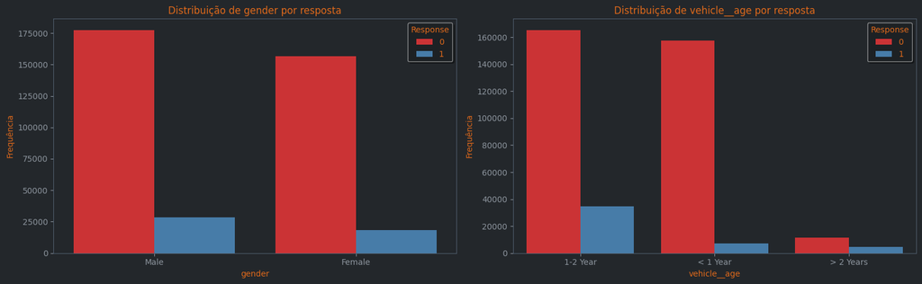

```python
categorical_vars = df_categorical.columns

fig, axes = plt.subplots(1, 2, figsize=(16, 5))

for idx, var in enumerate(categorical_vars):
    df_plot = df1.copy()
    df_plot[var] = df_plot[var].astype(str)
    order = df_plot[var].value_counts().index
    sns.countplot(data=df_plot, x=var, hue='response', palette='Set1', order=order, ax=axes[idx])
    axes[idx].set_title(f'Distribuição de {var} por resposta')
    axes[idx].set_xlabel(var)
    axes[idx].set_ylabel('Frequência')
    axes[idx].legend(title='Response')

plt.tight_layout()
plt.show()
```

**Gender:**

A distribuição mostra uma leve predominância do gênero masculino entre os clientes, tanto no grupo que não respondeu (Response = 0) quanto no grupo que respondeu positivamente (Response = 1). Contudo, observa-se que homens apresentam um número absoluto maior de respostas positivas em comparação às mulheres, indicando uma propensão ligeiramente superior à adesão entre o público masculino. Apesar disso, a diferença não é abrupta, sugerindo que o gênero não é o fator isolado mais determinante na resposta à campanha.

**Vehicle Age:**

Clientes com veículos entre 1 e 2 anos representam a maior parcela da base e concentram também o maior número de respostas positivas, o que pode indicar maior interesse de renovação ou upgrade de seguro nessa faixa de idade do veículo. Já os veículos com menos de 1 ano apresentam alta frequência total, mas baixa taxa de resposta, possivelmente porque clientes com veículos muito novos ainda se sentem protegidos pelo seguro original. Em contraste, veículos com mais de 2 anos têm volume reduzido, mas mantêm uma proporção razoável de respostas, o que pode representar um segmento mais fiel ou de maior necessidade de proteção devido à idade do automóvel.

## 6. Feature Engineering

```python
df2 = df1
```

### 6.1 Criação de Hipóteses

H1 — Clientes mais velhos (age) têm maior probabilidade de adquirir o seguro.

H2 — Clientes que possuem carteira de motorista (driving_license = 1) têm maior probabilidade de compra.

H3 — Clientes com histórico de seguro anterior (previously_insured = 1) têm menor propensão a contratar novamente.

H4 — Veículos mais novos (vehicle_age = “< 1 year”) estão associados a maior taxa de contratação.

H5 — Clientes cujo veículo sofreu danos anteriores (vehicle_damage = 1) apresentam maior probabilidade de contratar o seguro.

H6 — Clientes com prêmios anuais (annual_premium) mais altos tendem a ter menor taxa de conversão.

H7 — Determinadas regiões (region_code) apresentam maior propensão à compra de seguro.

H8 — O canal de venda (policy_sales_channel) influencia significativamente a taxa de conversão.

H9 — Clientes com maior tempo de relacionamento (vintage) com a empresa têm maior probabilidade de aceitar a oferta.

H10 — O gênero (gender) influencia a propensão à compra de seguro.

H11 — Clientes com maior vehicle_risk apresentam menor probabilidade de adquirir um novo seguro.

### 6.2 Derivando Variáveis

#### 6.2.1 Codificação Numérica e Features Básicas

```python
df2['vehicle_age_num'] = df2['vehicle__age'].map({'< 1 Year': 0, '1-2 Year': 1, '> 2 Years': 2})
df2 = df2.drop(columns=['vehicle__age'])
df2['vehicle_risk'] = df2['vehicle_age_num'] + df2['vehicle__damage']
df2['premium_per_vintage'] = df2['annual__premium'] / df2['vintage']
df2['premium_per_age'] = df2['annual__premium'] / df2['age']
df2['premium_per_risk'] = df2['annual__premium'] / (df2['vehicle_risk'] + 1e-5)
df2['age_x_premium'] = df2['age'] * df2['annual__premium']
df2['age_x_vehicle_age_num'] = df2['age'] * df2['vehicle_age_num']
df2['damage_x_age_vehicle'] = df2['vehicle__damage'] * df2['vehicle_age_num']
df2['age_x_vintage'] = df2['age'] * df2['vintage']
df2['age_bucket'] = pd.cut(df2['age'], bins=[18, 30, 40, 50, 60, 100], labels=[0, 1, 2, 3, 4])
df2['age_x_bucket'] = df2['age'] * df2['age_bucket'].astype(int)
df2['premium_bucket'] = pd.qcut(df2['annual__premium'], q=5, labels=False)
df2['vintage_per_age'] = df2['vintage'] / df2['age']
df2['vintage_per_year'] = df2['vintage'] / 12
df2['age_squared'] = df2['age'] ** 2
df2['age_cubed'] = df2['age'] ** 3
```

#### 6.2.2 Estatísticas por Região e Canal

```python
region_counts = df2['region__code'].value_counts(normalize=True)
df2['region__popularity'] = df2['region__code'].map(region_counts)
channel_counts = df2['policy__sales__channel'].value_counts(normalize=True)
df2['channel_popularity'] = df2['policy__sales__channel'].map(channel_counts)
df2['region__avg_premium'] = df2['region__code'].map(
    df2.groupby('region__code')['annual__premium'].mean()
)
df2['policy__channel__avg_premium'] = df2['policy__sales__channel'].map(
    df2.groupby('policy__sales__channel')['annual__premium'].mean()
)
df2['premium_minus_region_avg'] = df2['annual__premium'] - df2['region__avg_premium']
conversion_by_region = df2.groupby('region__code')['response'].mean()
df2['region_conversion_rate'] = df2['region__code'].map(conversion_by_region)
```

#### 6.2.3 Outras Features Compostas

```python
df2['insurance_need_score'] = (
    (df2['previously__insured'] == 0).astype(int) * 2 +
    df2['vehicle_risk'] +
    df2['vehicle__damage']
)
avg_premium_by_risk = df2.groupby('vehicle_risk')['annual__premium'].mean()
df2['premium_diff_risk'] = df2['annual__premium'] - df2['vehicle_risk'].map(avg_premium_by_risk)
df2['channel_x_previously'] = df2['policy__sales__channel'] * df2['previously__insured']
df2['channel_x_risk'] = df2['policy__sales__channel'] * df2['vehicle_risk']
df2['is_new_customer'] = (df2['vintage'] < df2['vintage'].median()).astype(int)
df2['avg_premium_same_age'] = df2.groupby('age')['annual__premium'].transform('mean')
df2['premium_rel_age'] = df2['annual__premium'] / df2['avg_premium_same_age']
df2['premium_age_percentile'] = df2.groupby('age')['annual__premium'].rank(pct=True)
df2['risk_alignment'] = df2['insurance_need_score'] * df2['vehicle_risk']
```

## 7. Análise Exploratória de Dados

```python
df3 = df2.copy()
```

### 7.1 Análise Univariada

#### 7.1.1 Variável Resposta

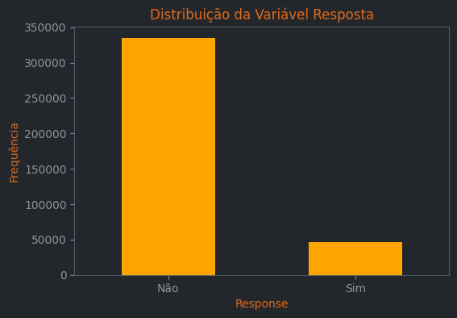

```python
plt.figure(figsize=(6,4))
df3['response'].value_counts().plot(kind='bar', color='orange')
plt.title('Distribuição da Variável Resposta')
plt.xlabel('Response')
plt.ylabel('Frequência')
plt.xticks([0,1], ['Não', 'Sim'], rotation=0)
plt.show()
```

A variável Response apresenta uma distribuição altamente desbalanceada, com predominância expressiva da classe "Não" em relação à classe "Sim". Isso indica que a maioria dos clientes não aderiu ao seguro, enquanto apenas uma pequena parcela demonstrou resposta positiva à campanha. Esse tipo de desbalanceamento é comum em problemas de classificação binária voltados à previsão de comportamento de compra, mas pode prejudicar o desempenho do modelo, levando-o a favorecer a classe majoritária e a ignorar padrões importantes da classe minoritária.

Para corrigir essa discrepância e permitir que o modelo aprenda adequadamente os padrões das duas classes, será necessário aplicar técnicas de balanceamento de dados, como oversampling (por exemplo, SMOTE ou RandomOverSampler) ou undersampling, dependendo da estratégia e do volume de dados disponíveis. Essas técnicas ajudarão a garantir que o modelo não seja enviesado e consiga identificar com maior precisão os clientes com maior propensão à resposta positiva.

#### 7.1.2 Variáveis Númericas

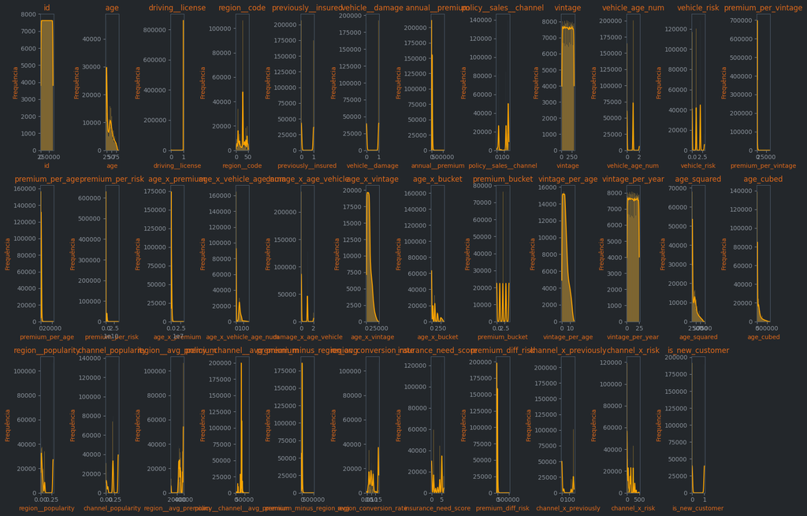

```python
numerical_cols = [col for col in df3.select_dtypes(include=['int64', 'float64']).columns if col != 'response']

plt.figure(figsize=(18, 12))
for i, col in enumerate(numerical_cols, 1):
    plt.subplot(3, int(np.ceil(len(numerical_cols)/3)), i)
    sns.histplot(df3[col], bins=50, kde=True, color='orange')
    plt.title(col)
    plt.xlabel(col)
    plt.ylabel('Frequência')
plt.tight_layout()
plt.show()
```

Age: A distribuição é fortemente concentrada entre 20 e 40 anos, com queda gradual em faixas etárias mais altas. Isso indica que a base é composta majoritariamente por clientes jovens, que tendem a ter maior propensão à aquisição de seguros de menor valor.

Driving_license: A quase totalidade dos registros possui carteira de habilitação válida, o que é esperado, visto que o produto está associado a veículos. Essa variável, portanto, tem baixa variabilidade e pouca capacidade discriminativa.

Region_code: A distribuição mostra picos específicos em alguns códigos, sugerindo concentração geográfica de clientes em determinadas regiões. Isso pode refletir mercados locais mais ativos ou com maior penetração da campanha.

Annual_premium: A variável apresenta assimetria à direita, com poucos valores muito altos. Isso sugere que a maior parte dos clientes adquire seguros de baixo custo, enquanto poucos contratam planos caros.

Policy_sales_channel: Alguns canais concentram a maioria das vendas, indicando que certas abordagens (como call centers ou parceiros específicos) são mais efetivas.

Vintage: A distribuição é praticamente uniforme, o que sugere que há clientes com variados tempos de relacionamento, sem concentração em faixas específicas.

Premium_per_vintage: Fortemente concentrada em valores baixos, o que mostra que a maioria dos clientes paga prêmios modestos em relação ao tempo de relacionamento.

Premium_per_age: Assimetria acentuada à direita, clientes mais jovens tendem a pagar prêmios proporcionais mais altos, refletindo políticas de risco por faixa etária.

Region_popularity: Observa-se concentração crescente nas últimas categorias, sugerindo que poucas regiões concentram grande parte da base de clientes, o que pode refletir atuação geográfica desigual ou campanhas regionais mais fortes.

Vehicle Age: Há uma concentração de pessoas com veículos com menos de 1 ano e de 1 a 2 anos de uso, com uma baixíssima quantidade de veiculos que possuem mais de 2 anos.

#### 7.1.3 Variáveis Categóricas

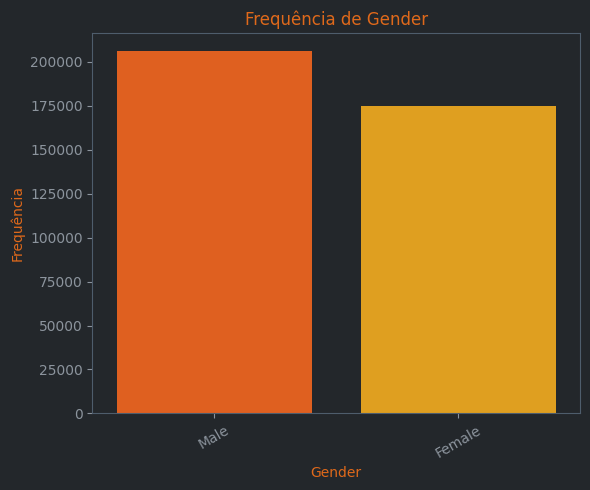

```python
categorical_cols = [
    'gender',
]

warm_palette = sns.color_palette("autumn", n_colors=df3[categorical_cols[0]].nunique())

plt.figure(figsize=(6 * len(categorical_cols), 5))
for i, col in enumerate(categorical_cols, 1):
    plt.subplot(1, len(categorical_cols), i)
    order = df3[col].value_counts().index
    n_unique = df3[col].nunique()
    palette = sns.color_palette("autumn", n_colors=n_unique)
    sns.countplot(data=df3, x=col, order=order, palette=palette)
    plt.title(f'Frequência de {col.replace("__", " ").capitalize()}')
    plt.xticks(rotation=30)
    plt.xlabel(col.replace("__", " ").capitalize())
    plt.ylabel('Frequência')
plt.tight_layout()
plt.show()
```

### 7.2 Análise Bivariada

#### H1 — Clientes mais velhos (age) têm maior probabilidade de adquirir o seguro. Verdadeira

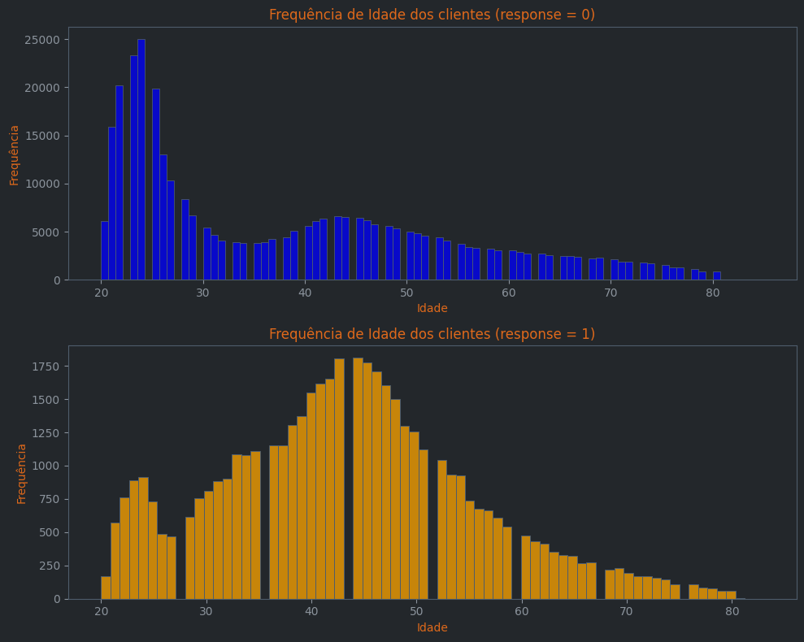

```python
fig, axes = plt.subplots(2, 1, figsize=(10, 8), sharey=False)

sns.histplot(data=df3[df3['response'] == 0], x='age', color='blue', ax=axes[0])
axes[0].set_title('Frequência de Idade dos clientes (response = 0)')
axes[0].set_ylabel('Frequência')
axes[0].set_xlabel('Idade')

sns.histplot(data=df3[df3['response'] == 1], x='age', color='orange', ax=axes[1])
axes[1].set_title('Frequência de Idade dos clientes (response = 1)')
axes[1].set_ylabel('Frequência')
axes[1].set_xlabel('Idade')

plt.tight_layout()
plt.show()
```

```python
pearson_corr = df3['age'].corr(df3['response'], method='pearson')
print(f"Correlação de Pearson entre age e response: {pearson_corr:.4f}")
```

```
Correlação de Pearson entre age e response: 0.1111
```

#### H2 — Clientes que possuem carteira de motorista (driving_license = 1) têm maior probabilidade de compra. FALSA

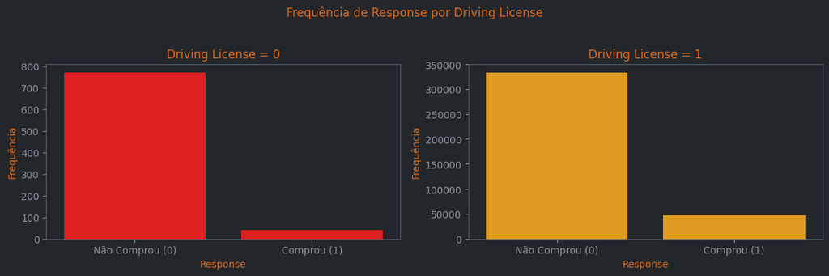

```python
fig, axes = plt.subplots(1, 2, figsize=(12, 4), sharey=False)

for i, val in enumerate(sorted(df3['driving__license'].unique())):
    sns.countplot(
        data=df3[df3['driving__license'] == val],
        x='response',
        color="red" if val == 0 else "orange",
        ax=axes[i]
    )
    axes[i].set_title(f'Driving License = {val}')
    axes[i].set_xlabel('Response')
    axes[i].set_ylabel('Frequência')
    axes[i].set_xticks([0, 1])
    axes[i].set_xticklabels(['Não Comprou (0)', 'Comprou (1)'])

plt.suptitle('Frequência de Response por Driving License')
plt.tight_layout(rect=[0, 0, 1, 0.95])
plt.show()
```

```python
contingency_table = pd.crosstab(df3['driving__license'], df3['response'])

chi2, p, dof, expected = chi2_contingency(contingency_table)

n = contingency_table.sum().sum()
min_dim = min(contingency_table.shape) - 1
cramers_v = np.sqrt(chi2 / (n * min_dim)) if min_dim > 0 else np.nan

print(f"V de Cramer entre driving_license e response: {cramers_v:.4f}")
```

```
V de Cramer entre driving_license e response: 0.0101
```

#### H3 — Clientes com histórico de seguro anterior (previously_insured = 1) têm menor propensão a contratar novamente. VERDADEIRA

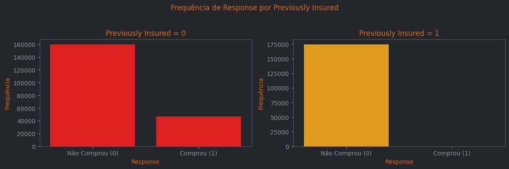

```python
fig, axes = plt.subplots(1, 2, figsize=(12, 4), sharey=False)

for i, val in enumerate(sorted(df3['previously__insured'].unique())):
    sns.countplot(
        data=df3[df3['previously__insured'] == val],
        x='response',
        color="red" if val == 0 else "orange",
        ax=axes[i]
    )
    axes[i].set_title(f'Previously Insured = {val}')
    axes[i].set_xlabel('Response')
    axes[i].set_ylabel('Frequência')
    axes[i].set_xticks([0, 1])
    axes[i].set_xticklabels(['Não Comprou (0)', 'Comprou (1)'])

plt.suptitle('Frequência de Response por Previously Insured')
plt.tight_layout(rect=[0, 0, 1, 0.95])
plt.show()
```

```python
contingency_table = pd.crosstab(df3['previously__insured'], df3['response'])

chi2, p, dof, expected = chi2_contingency(contingency_table)

n = contingency_table.sum().sum()
min_dim = min(contingency_table.shape) - 1
cramers_v = np.sqrt(chi2 / (n * min_dim)) if min_dim > 0 else np.nan

print(f"V de Cramer entre previously__insured e response: {cramers_v:.4f}")
```

```
V de Cramer entre previously__insured e response: 0.3412
```

#### H4 — Veículos mais novos estão associados a maior taxa de contratação. FALSA

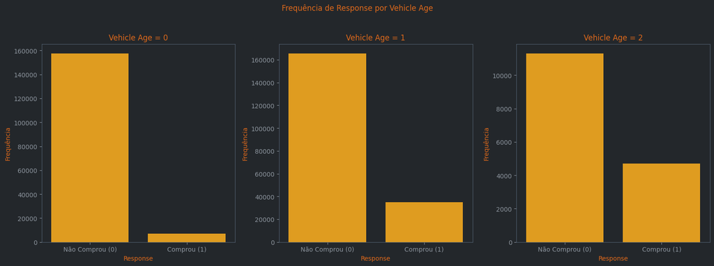

```python
vehicle_age_values = [0, 1, 2]

fig, axes = plt.subplots(1, len(vehicle_age_values), figsize=(16, 6), sharey=False)

for i, val in enumerate(vehicle_age_values):
    sns.countplot(
        data=df3[df3['vehicle_age_num'] == val],
        x='response',
        color="orange",
        ax=axes[i]
    )
    axes[i].set_title(f'Vehicle Age = {val}')
    axes[i].set_xlabel('Response')
    axes[i].set_ylabel('Frequência')
    axes[i].set_xticks([0, 1])
    axes[i].set_xticklabels(['Não Comprou (0)', 'Comprou (1)'])

plt.suptitle('Frequência de Response por Vehicle Age')
plt.tight_layout(rect=[0, 0, 1, 0.95])
plt.show()
```

```python
pearson_corr = df3['vehicle_age_num'].corr(df3['response'], method='pearson')
print(f"Correlação de Pearson entre vehicle__age_num e response: {pearson_corr:.4f}")
```

```
Correlação de Pearson entre vehicle__age_num e response: 0.2219
```

#### H5 — Clientes cujo veículo sofreu danos anteriores (vehicle_damage = 1) apresentam maior probabilidade de contratar o seguro. VERDADEIRA

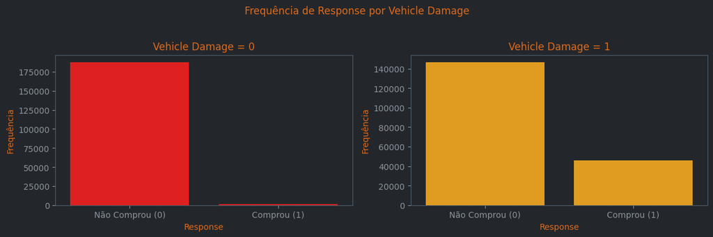

```python
fig, axes = plt.subplots(1, 2, figsize=(12, 4), sharey=False)

for i, val in enumerate(sorted(df3['vehicle__damage'].unique())):
    sns.countplot(
        data=df3[df3['vehicle__damage'] == val],
        x='response',
        color="red" if val == 0 else "orange",
        ax=axes[i]
    )
    axes[i].set_title(f'Vehicle Damage = {val}')
    axes[i].set_xlabel('Response')
    axes[i].set_ylabel('Frequência')
    axes[i].set_xticks([0, 1])
    axes[i].set_xticklabels(['Não Comprou (0)', 'Comprou (1)'])

plt.suptitle('Frequência de Response por Vehicle Damage')
plt.tight_layout(rect=[0, 0, 1, 0.95])
plt.show()
```

```python
contingency_table = pd.crosstab(df3['vehicle__damage'], df3['response'])

chi2, p, dof, expected = chi2_contingency(contingency_table)

n = contingency_table.sum().sum()
min_dim = min(contingency_table.shape) - 1
cramers_v = np.sqrt(chi2 / (n * min_dim)) if min_dim > 0 else np.nan

print(f"V de Cramer entre vehicle__damage e response: {cramers_v:.4f}")
```

```
V de Cramer entre vehicle__damage e response: 0.3544
```

#### H6 — Clientes com prêmios anuais (annual_premium) mais altos tendem a ter menor taxa de conversão. FALSA

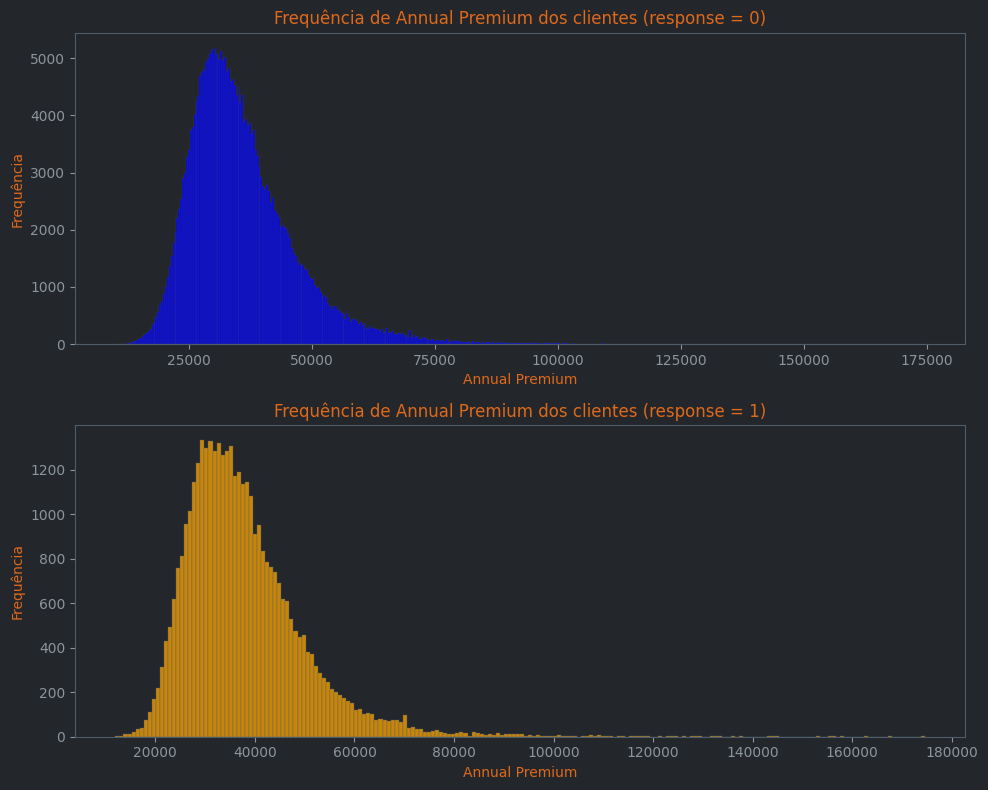

```python
df_filtrado = df3[(df3['annual__premium'] > 10000) & (df3['annual__premium'] < 175000)]

fig, axes = plt.subplots(2, 1, figsize=(10, 8), sharey=False)

sns.histplot(data=df_filtrado[df_filtrado['response'] == 0], x='annual__premium', color='blue', ax=axes[0])
axes[0].set_title('Frequência de Annual Premium dos clientes (response = 0)')
axes[0].set_ylabel('Frequência')
axes[0].set_xlabel('Annual Premium')

sns.histplot(data=df_filtrado[df_filtrado['response'] == 1], x='annual__premium', color='orange', ax=axes[1])
axes[1].set_title('Frequência de Annual Premium dos clientes (response = 1)')
axes[1].set_ylabel('Frequência')
axes[1].set_xlabel('Annual Premium')

plt.tight_layout()
plt.show()
```

```python
pearson_corr = df3['annual__premium'].corr(df3['response'], method='pearson')
print(f"Correlação de Pearson entre annual premium e response: {pearson_corr:.4f}")
```

```
Correlação de Pearson entre annual premium e response: 0.0226
```

#### H7 — Determinadas regiões (region_code) apresentam maior propensão à compra de seguro. FALSA

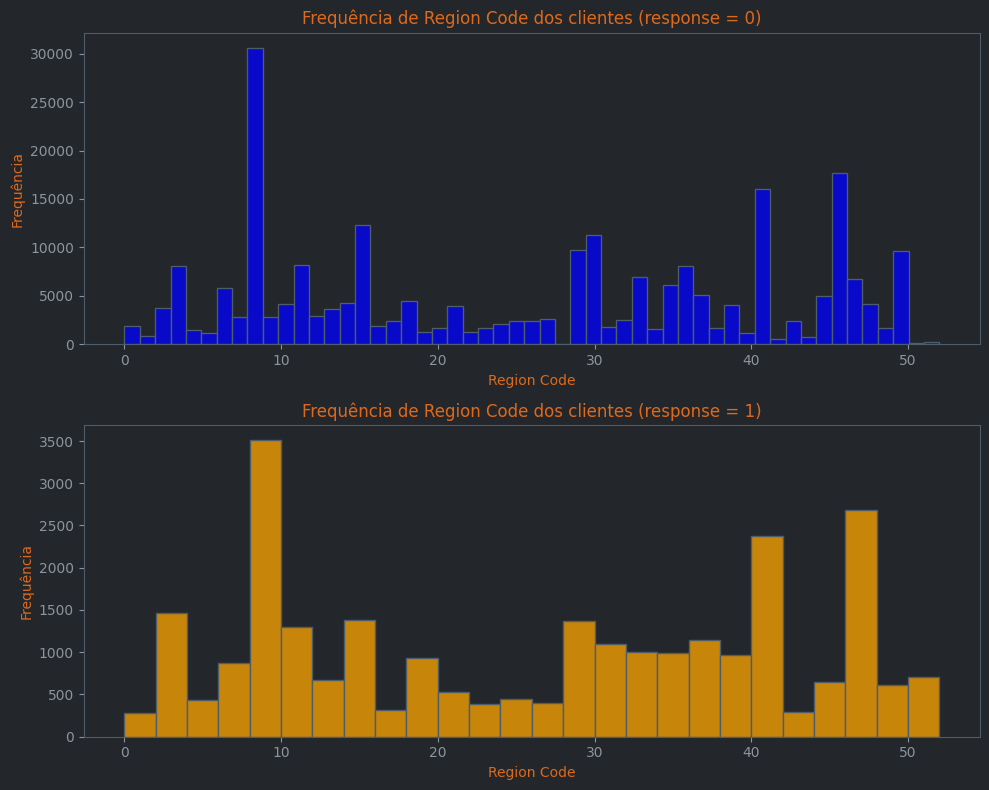

```python
df_region28 = df3[df3['region__code'] != 28]

fig, axes = plt.subplots(2, 1, figsize=(10, 8), sharey=False)

sns.histplot(data=df_region28[df_region28['response'] == 0], x='region__code', color='blue', ax=axes[0])
axes[0].set_title('Frequência de Region Code dos clientes (response = 0)')
axes[0].set_ylabel('Frequência')
axes[0].set_xlabel('Region Code')

sns.histplot(data=df_region28[df_region28['response'] == 1], x='region__code', color='orange', ax=axes[1])
axes[1].set_title('Frequência de Region Code dos clientes (response = 1)')
axes[1].set_ylabel('Frequência')
axes[1].set_xlabel('Region Code')

plt.tight_layout()
plt.show()
```

```python
pearson_corr = df3['region__code'].corr(df3['response'], method='pearson')
print(f"Correlação de Pearson entre region code e response: {pearson_corr:.4f}")
```

```
Correlação de Pearson entre region code e response: 0.0106
```

#### H8 — O canal de venda (policy_sales_channel) influencia significativamente a taxa de conversão. VERDADEIRA

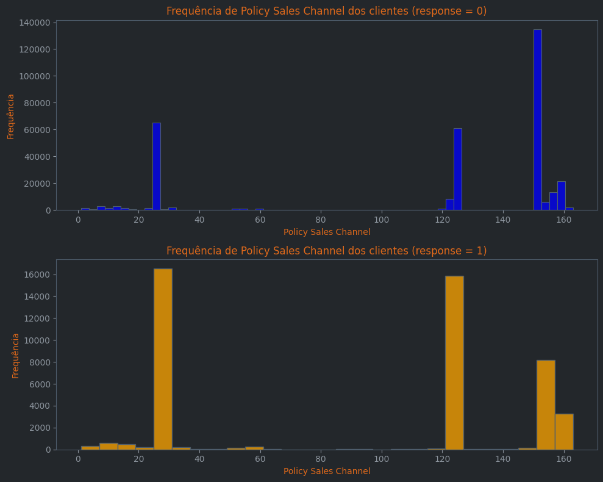

```python
fig, axes = plt.subplots(2, 1, figsize=(10, 8), sharey=False)

sns.histplot(data=df3[df3['response'] == 0], x='policy__sales__channel', color='blue', ax=axes[0])
axes[0].set_title('Frequência de Policy Sales Channel dos clientes (response = 0)')
axes[0].set_ylabel('Frequência')
axes[0].set_xlabel('Policy Sales Channel')

sns.histplot(data=df3[df3['response'] == 1], x='policy__sales__channel', color='orange', ax=axes[1])
axes[1].set_title('Frequência de Policy Sales Channel dos clientes (response = 1)')
axes[1].set_ylabel('Frequência')
axes[1].set_xlabel('Policy Sales Channel')

plt.tight_layout()
plt.show()
```

```python
pearson_corr = df3['policy__sales__channel'].corr(df3['response'], method='pearson')
print(f"Correlação de Pearson entre policy sales channel e response: {pearson_corr:.4f}")
```

```
Correlação de Pearson entre policy sales channel e response: -0.1390
```

#### H9 — Clientes com maior tempo de relacionamento (vintage) com a empresa têm maior probabilidade de aceitar a oferta. FALSA

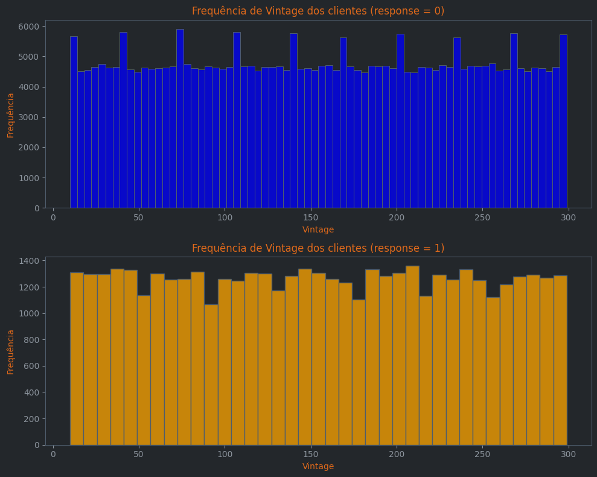

```python
fig, axes = plt.subplots(2, 1, figsize=(10, 8), sharey=False)

sns.histplot(data=df3[df3['response'] == 0], x='vintage', color='blue', ax=axes[0])
axes[0].set_title('Frequência de Vintage dos clientes (response = 0)')
axes[0].set_ylabel('Frequência')
axes[0].set_xlabel('Vintage')

sns.histplot(data=df3[df3['response'] == 1], x='vintage', color='orange', ax=axes[1])
axes[1].set_title('Frequência de Vintage dos clientes (response = 1)')
axes[1].set_ylabel('Frequência')
axes[1].set_xlabel('Vintage')

plt.tight_layout()
plt.show()
```

```python
pearson_corr = df3['vintage'].corr(df3['response'], method='pearson')
print(f"Correlação de Pearson entre vintage e response: {pearson_corr:.4f}")
```

```
Correlação de Pearson entre vintage e response: -0.0011
```

#### H10 — O gênero (gender) influencia a propensão à compra de seguro. FALSA

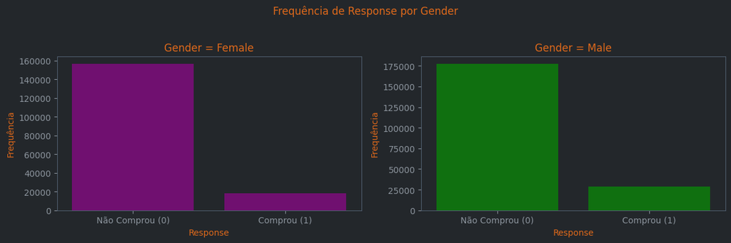

```python
fig, axes = plt.subplots(1, 2, figsize=(12, 4), sharey=False)

for i, val in enumerate(sorted(df3['gender'].unique())):
    sns.countplot(
        data=df3[df3['gender'] == val],
        x='response',
        color="green" if val == 'Male' else "purple",
        ax=axes[i]
    )
    axes[i].set_title(f'Gender = {val}')
    axes[i].set_xlabel('Response')
    axes[i].set_ylabel('Frequência')
    axes[i].set_xticks([0, 1])
    axes[i].set_xticklabels(['Não Comprou (0)', 'Comprou (1)'])

plt.suptitle('Frequência de Response por Gender')
plt.tight_layout(rect=[0, 0, 1, 0.95])
plt.show()
```

```python
contingency_table = pd.crosstab(df3['gender'], df3['response'])

chi2, p, dof, expected = chi2_contingency(contingency_table)

n = contingency_table.sum().sum()
min_dim = min(contingency_table.shape) - 1
cramers_v = np.sqrt(chi2 / (n * min_dim)) if min_dim > 0 else np.nan

print(f"V de Cramer entre gender e response: {cramers_v:.4f}")
```

```
V de Cramer entre gender e response: 0.0524
```

#### H11 — Clientes com maior vehicle_risk apresentam maior probabilidade de adquirir um novo seguro. VERDADEIRA

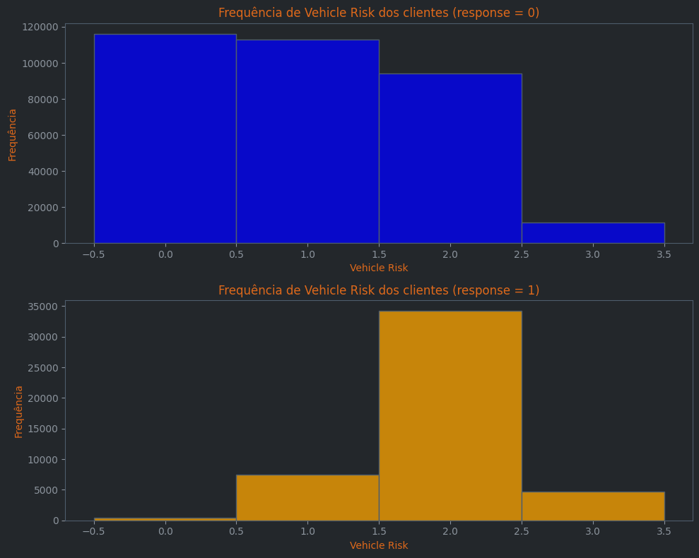

```python
fig, axes = plt.subplots(2, 1, figsize=(10, 8), sharey=False)

sns.histplot(data=df3[df3['response'] == 0], x='vehicle_risk', color='blue', ax=axes[0], discrete = True)
axes[0].set_title('Frequência de Vehicle Risk dos clientes (response = 0)')
axes[0].set_ylabel('Frequência')
axes[0].set_xlabel('Vehicle Risk')

sns.histplot(data=df3[df3['response'] == 1], x='vehicle_risk', color='orange', ax=axes[1], discrete = True)
axes[1].set_title('Frequência de Vehicle Risk dos clientes (response = 1)')
axes[1].set_ylabel('Frequência')
axes[1].set_xlabel('Vehicle Risk')

plt.tight_layout()
plt.show()
```

```python
pearson_corr = df3['vehicle_risk'].corr(df3['response'], method='pearson')
print(f"Correlação de Pearson entre vehicle risk e response: {pearson_corr:.4f}")
```

```
Correlação de Pearson entre vehicle risk e response: 0.3395
```

## 8. Preparação dos dados

```python
df4 = df3.copy()
```

### 8.1 Scaler

#### 8.1.1 Log Transformation

```python
log_transform_cols = [
    'age_x_premium',
    'premium_per_risk',
    'premium_per_age',
    'premium_per_vintage'
]

for col in log_transform_cols:
    df4[col + '_log'] = np.log1p(df4[col])
    df4.drop(columns=col, inplace=True)
```

#### 8.1.2 Standard Scaler

```python
cols_to_scale_standard = [
    'age',
    'vintage',
    'vintage_per_age',
    'region__popularity',
    'channel_x_risk',
    'channel_x_previously',
    'insurance_need_score',
    'channel_popularity',
    'age_x_bucket',
    'age_x_vintage',
    'vehicle_age_num',
    'premium_rel_age',
    'damage_x_age_vehicle',
    'age_x_vehicle_age_num',
    'risk_alignment',
    'vehicle_risk',
    'annual__premium',
    'premium_per_age_log',
    'premium_per_vintage_log',
    'age_x_premium_log',
    'premium_bucket',
    'region__avg_premium',
    'policy__channel__avg_premium',
    'premium_diff_risk',
    'premium_per_risk_log',
    'premium_minus_region_avg',
    'age_cubed',
    'vintage_per_year',
    'avg_premium_same_age',
    'age_squared'
]

standard_scaler = StandardScaler()
df4[cols_to_scale_standard] = standard_scaler.fit_transform(df4[cols_to_scale_standard])
```

#### 8.1.4 MinMaxScaler

```python
cols_to_scale_minmax = [
    'region_conversion_rate',
    'premium_age_percentile',
]

minmax_scaler = MinMaxScaler()
df4[cols_to_scale_minmax] = minmax_scaler.fit_transform(df4[cols_to_scale_minmax])
```

### 8.2 Encoding

#### 8.2.1 One Hot Encoding

```python
df4['gender'] = df4['gender'].map({'Male': 1, 'Female': 0})

ohe_age = OneHotEncoder(sparse_output=False, dtype=int, drop=None)
age_bucket_encoded = ohe_age.fit_transform(df4[['age_bucket']])
age_bucket_columns = [f'age_bucket_{cat}' for cat in ohe_age.categories_[0]]
df4[age_bucket_columns] = age_bucket_encoded
df4 = df4.drop('age_bucket', axis=1)

ohe_premium = OneHotEncoder(sparse_output=False, dtype=int, drop=None)
premium_bucket_encoded = ohe_premium.fit_transform(df4[['premium_bucket']])
premium_bucket_columns = [f'premium_bucket_{cat}' for cat in ohe_premium.categories_[0]]
df4[premium_bucket_columns] = premium_bucket_encoded
df4 = df4.drop('premium_bucket', axis=1)
```

#### 8.2.3 Target Encoding

```python
region_code_target_mean = df4.groupby('region__code')['response'].mean()
df4['region__code'] = df4['region__code'].map(region_code_target_mean)
```

#### 8.2.4 Frequency Encoding

```python
policy_sales_freq = df4['policy__sales__channel'].value_counts(normalize=True)
df4['policy__sales__channel'] = df4['policy__sales__channel'].map(policy_sales_freq)
```

## 9. Feature Selection

```python
df5 = df4.copy()
```

### 9.1 Features Importance

```python
response = df5['response']
num_neg = (response == 0).sum()
num_pos = (response == 1).sum()
scale_pos_weight = num_neg / num_pos

X = df5.drop(['id', 'response'], axis=1)
y = df5['response']

xgbm_model = xgb.XGBClassifier(
    n_estimators=300,
    random_state=42,
    n_jobs=-1,
    scale_pos_weight=scale_pos_weight,
    eval_metric='logloss'
)
xgbm_model.fit(X, y)

lgbm_model = lgb.LGBMClassifier(
    n_estimators=300,
    random_state=42,
    n_jobs=-1,
    scale_pos_weight=scale_pos_weight
)
lgbm_model.fit(X, y)

cat_model = CatBoostClassifier(
    iterations=300,
    random_state=42,
    verbose=0,
    scale_pos_weight=scale_pos_weight
)
cat_model.fit(X, y)

shap_sample = X.sample(n=min(1000, len(X)), random_state=42)

explainer_xgb = shap.TreeExplainer(xgbm_model)
shap_values_xgb = explainer_xgb.shap_values(shap_sample)
mean_abs_shap_xgb = np.abs(shap_values_xgb).mean(axis=0)

feat_importance_xgb = pd.DataFrame({
    'Feature': X.columns,
    'SHAP_XGB': mean_abs_shap_xgb
})

explainer_lgb = shap.TreeExplainer(lgbm_model)
shap_values_lgb = explainer_lgb.shap_values(shap_sample)
if isinstance(shap_values_lgb, list):
    shap_values_lgb = shap_values_lgb[1]

mean_abs_shap_lgb = np.abs(shap_values_lgb).mean(axis=0)
feat_importance_lgb = pd.DataFrame({
    'Feature': X.columns,
    'SHAP_LGBM': mean_abs_shap_lgb
})

explainer_cat = shap.TreeExplainer(cat_model)
shap_values_cat = explainer_cat.shap_values(shap_sample)
if isinstance(shap_values_cat, (list, tuple)):
    shap_values_cat = shap_values_cat[1]

mean_abs_shap_cat = np.abs(shap_values_cat).mean(axis=0)
feat_importance_cat = pd.DataFrame({
    'Feature': X.columns,
    'SHAP_CAT': mean_abs_shap_cat
})

feat_importance_df = (
    feat_importance_xgb
        .merge(feat_importance_lgb, on='Feature')
        .merge(feat_importance_cat, on='Feature')
)

feat_importance_df['SHAP_XGB_NORM'] = feat_importance_df['SHAP_XGB'] / feat_importance_df['SHAP_XGB'].sum()
feat_importance_df['SHAP_LGBM_NORM'] = feat_importance_df['SHAP_LGBM'] / feat_importance_df['SHAP_LGBM'].sum()
feat_importance_df['SHAP_CAT_NORM'] = feat_importance_df['SHAP_CAT'] / feat_importance_df['SHAP_CAT'].sum()

feat_importance_df['SHAP_MEAN_NORM'] = feat_importance_df[
    ['SHAP_XGB_NORM', 'SHAP_LGBM_NORM', 'SHAP_CAT_NORM']
].mean(axis=1)

feat_importance_df = feat_importance_df.sort_values(by='SHAP_MEAN_NORM', ascending=False).reset_index(drop=True)
```

```python
feat_importance_df
```

|  | Feature | SHAP_XGB | SHAP_LGBM | SHAP_CAT | SHAP_XGB_NORM | SHAP_LGBM_NORM | SHAP_CAT_NORM | SHAP_MEAN_NORM |
| --- | --- | --- | --- | --- | --- | --- | --- | --- |
| 0 | insurance_need_score | 1.869370 | 6.455720 | 1.764425 | 0.264343 | 0.182554 | 0.245844 | 0.230914 |
| 1 | region__code | 0.226041 | 6.332411 | 0.143048 | 0.031964 | 0.179068 | 0.019931 | 0.076988 |
| 2 | vintage_per_age | 0.182051 | 4.956382 | 0.233489 | 0.025743 | 0.140156 | 0.032533 | 0.066144 |
| 3 | channel_x_previously | 0.725582 | 1.561159 | 0.202481 | 0.102603 | 0.044146 | 0.028212 | 0.058320 |
| 4 | previously__insured | 0.420138 | 0.495890 | 0.614735 | 0.059411 | 0.014023 | 0.085653 | 0.053029 |
| 5 | vintage | 0.117089 | 2.065337 | 0.241974 | 0.016557 | 0.058403 | 0.033715 | 0.036225 |
| 6 | age_x_vintage | 0.185885 | 2.069994 | 0.114016 | 0.026286 | 0.058535 | 0.015886 | 0.033569 |
| 7 | age | 0.306298 | 0.640326 | 0.200282 | 0.043313 | 0.018107 | 0.027906 | 0.029775 |
| 8 | premium_per_risk_log | 0.165245 | 1.297706 | 0.138548 | 0.023367 | 0.036696 | 0.019304 | 0.026456 |
| 9 | channel_x_risk | 0.110616 | 0.228766 | 0.389521 | 0.015642 | 0.006469 | 0.054273 | 0.025461 |
| 10 | premium_minus_region_avg | 0.172885 | 1.228944 | 0.106557 | 0.024447 | 0.034752 | 0.014847 | 0.024682 |
| 11 | premium_per_vintage_log | 0.152583 | 0.932000 | 0.162916 | 0.021576 | 0.026355 | 0.022700 | 0.023544 |
| 12 | premium_age_percentile | 0.193682 | 0.435181 | 0.204263 | 0.027388 | 0.012306 | 0.028461 | 0.022718 |
| 13 | avg_premium_same_age | 0.088992 | 1.527295 | 0.072398 | 0.012584 | 0.043189 | 0.010087 | 0.021953 |
| 14 | age_cubed | 0.000000 | 0.000000 | 0.438375 | 0.000000 | 0.000000 | 0.061080 | 0.020360 |
| 15 | vehicle__damage | 0.358636 | 0.279770 | 0.000000 | 0.050714 | 0.007911 | 0.000000 | 0.019542 |
| 16 | premium_rel_age | 0.205864 | 0.391285 | 0.129303 | 0.029111 | 0.011065 | 0.018016 | 0.019397 |
| 17 | premium_diff_risk | 0.176098 | 0.517469 | 0.130016 | 0.024902 | 0.014633 | 0.018116 | 0.019217 |
| 18 | premium_per_age_log | 0.173519 | 0.378066 | 0.134689 | 0.024537 | 0.010691 | 0.018767 | 0.017998 |
| 19 | premium_bucket_4.267394361373278e-05 | 0.013757 | 1.718322 | 0.009032 | 0.001945 | 0.048591 | 0.001258 | 0.017265 |
| 20 | annual__premium | 0.202192 | 0.258016 | 0.112776 | 0.028591 | 0.007296 | 0.015713 | 0.017200 |
| 21 | policy__sales__channel | 0.203903 | 0.124027 | 0.135372 | 0.028833 | 0.003507 | 0.018862 | 0.017067 |
| 22 | age_x_premium_log | 0.157571 | 0.377574 | 0.098006 | 0.022282 | 0.010677 | 0.013656 | 0.015538 |
| 23 | region__popularity | 0.110103 | 0.525245 | 0.084771 | 0.015569 | 0.014853 | 0.011812 | 0.014078 |
| 24 | region__avg_premium | 0.109482 | 0.189021 | 0.118393 | 0.015482 | 0.005345 | 0.016496 | 0.012441 |
| 25 | policy__channel__avg_premium | 0.106926 | 0.086745 | 0.120796 | 0.015120 | 0.002453 | 0.016831 | 0.011468 |
| 26 | age_x_vehicle_age_num | 0.109211 | 0.064467 | 0.118547 | 0.015443 | 0.001823 | 0.016518 | 0.011261 |
| 27 | channel_popularity | 0.000000 | 0.072147 | 0.153705 | 0.000000 | 0.002040 | 0.021416 | 0.007819 |
| 28 | gender | 0.071416 | 0.038651 | 0.070599 | 0.010099 | 0.001093 | 0.009837 | 0.007010 |
| 29 | risk_alignment | 0.013341 | 0.009597 | 0.129249 | 0.001887 | 0.000271 | 0.018009 | 0.006722 |
| 30 | damage_x_age_vehicle | 0.000000 | 0.000887 | 0.137893 | 0.000000 | 0.000025 | 0.019213 | 0.006413 |
| 31 | age_bucket_1 | 0.025553 | 0.026395 | 0.079282 | 0.003613 | 0.000746 | 0.011047 | 0.005135 |
| 32 | vehicle_age_num | 0.027708 | 0.015605 | 0.065741 | 0.003918 | 0.000441 | 0.009160 | 0.004506 |
| 33 | age_x_bucket | 0.000000 | 0.003864 | 0.076869 | 0.000000 | 0.000109 | 0.010710 | 0.003607 |
| 34 | region_conversion_rate | 0.000000 | 0.000000 | 0.071627 | 0.000000 | 0.000000 | 0.009980 | 0.003327 |
| 35 | vintage_per_year | 0.000000 | 0.000000 | 0.056765 | 0.000000 | 0.000000 | 0.007909 | 0.002636 |
| 36 | age_bucket_3 | 0.007891 | 0.000696 | 0.038824 | 0.001116 | 0.000020 | 0.005410 | 0.002182 |
| 37 | age_squared | 0.000000 | 0.002528 | 0.032446 | 0.000000 | 0.000071 | 0.004521 | 0.001531 |
| 38 | premium_bucket_-0.7070627163465073 | 0.008500 | 0.003354 | 0.022064 | 0.001202 | 0.000095 | 0.003074 | 0.001457 |
| 39 | vehicle_risk | 0.023763 | 0.011524 | 0.003065 | 0.003360 | 0.000326 | 0.000427 | 0.001371 |
| 40 | age_bucket_2 | 0.020465 | 0.001393 | 0.007086 | 0.002894 | 0.000039 | 0.000987 | 0.001307 |
| 41 | premium_bucket_0.7071480642337348 | 0.009646 | 0.033718 | 0.004419 | 0.001364 | 0.000953 | 0.000616 | 0.000978 |
| 42 | premium_bucket_1.4142534545238556 | 0.013686 | 0.000000 | 0.000000 | 0.001935 | 0.000000 | 0.000000 | 0.000645 |
| 43 | driving__license | 0.006072 | 0.005784 | 0.005698 | 0.000859 | 0.000164 | 0.000794 | 0.000605 |
| 44 | age_bucket_4 | 0.000000 | 0.000000 | 0.002962 | 0.000000 | 0.000000 | 0.000413 | 0.000138 |
| 45 | is_new_customer | 0.000000 | 0.000000 | 0.000000 | 0.000000 | 0.000000 | 0.000000 | 0.000000 |
| 46 | age_bucket_0 | 0.000000 | 0.000000 | 0.000000 | 0.000000 | 0.000000 | 0.000000 | 0.000000 |
| 47 | premium_bucket_-1.4141681066366283 | 0.000000 | 0.000000 | 0.000000 | 0.000000 | 0.000000 | 0.000000 | 0.000000 |

```python
feat_importance_df_ordenado = feat_importance_df.sort_values(by='SHAP_MEAN_NORM', ascending=False).reset_index(drop=True)

feat_importance_df_ordenado['cumsum'] = feat_importance_df_ordenado['SHAP_MEAN_NORM'].cumsum()
total_importance = feat_importance_df_ordenado['SHAP_MEAN_NORM'].sum()
feat_importance_df_ordenado['cumsum_pct'] = feat_importance_df_ordenado['cumsum'] / total_importance

selected_95 = feat_importance_df_ordenado[feat_importance_df_ordenado['cumsum_pct'] <= 0.95]['Feature'].tolist()

if len(selected_95) < len(feat_importance_df_ordenado):
    selected_95.append(feat_importance_df_ordenado.iloc[len(selected_95)]['Feature'])

print(f"Quantidade de features para 95% SHAP: {len(selected_95)}")
print(selected_95)
```

[output not shown]

### 9.2 Removendo Colunas de Alta Correlação

```python
colunas_existentes = [col for col in selected_95 if col in X.columns]

colunas_corr = [col for col in colunas_existentes if col != 'response']
df_temp = X[colunas_corr]
corr_matrix = df_temp.corr().abs()

colunas_final = colunas_corr.copy()
colunas_removidas = []

for i in range(len(colunas_corr)):
    col1 = colunas_corr[i]
    for j in range(i + 1, len(colunas_corr)):
        col2 = colunas_corr[j]
        if col1 in colunas_final and col2 in colunas_final:
            corr_value = corr_matrix.loc[col1, col2]
            if isinstance(corr_value, (pd.Series, pd.DataFrame)):
                corr_scalar = float(np.array(corr_value).flatten()[0])
            else:
                corr_scalar = float(corr_value)
            if corr_scalar > 0.9:
                if col2 in colunas_final:
                    colunas_final.remove(col2)
                    colunas_removidas.append((col1, col2, corr_scalar))

print("Colunas removidas devido alta correlação (>0.9):")
for c1, c2, val in colunas_removidas:
    print(f"{c2} removida (corr. com {c1} = {val:.3f})")

colunas_final = [*colunas_final, 'response'] if 'response' in X.columns else colunas_final

X = X[colunas_final]
```

```
Colunas removidas devido alta correlação (>0.9):
previously__insured removida (corr. com insurance_need_score = 0.926)
vehicle__damage removida (corr. com insurance_need_score = 0.930)
age_cubed removida (corr. com age = 0.946)
premium_diff_risk removida (corr. com premium_minus_region_avg = 0.904)
annual__premium removida (corr. com premium_minus_region_avg = 0.903)
channel_popularity removida (corr. com policy__sales__channel = 1.000)
```

## 10. Machine Learning

```python
X.to_csv('X.csv', index=False)
y.to_csv('y.csv', index=False)
```

```python
X_temp, X_test, y_temp, y_test = train_test_split(
    X, y, test_size=0.2, stratify=y, random_state=42
)

X_train, X_val, y_train, y_val = train_test_split(
    X_temp, y_temp, test_size=0.2, stratify=y_temp, random_state=42
)
```

### 10.1 KNN

```python
knn = KNeighborsClassifier(n_neighbors=7)
```

```python
knn.fit(X_train, y_train)

df_metricas = avaliar_metricas(knn, X_val, y_val, X_test, y_test)
display(df_metricas)
```

|  | validacao | teste |
| --- | --- | --- |
| recall | 0.151726 | 0.144616 |
| precision | 0.350541 | 0.341420 |
| f1_score | 0.211784 | 0.203173 |
| auc_roc | 0.787184 | 0.782758 |
| auc_pr | 0.281412 | 0.276875 |

### 10.2 Logistic Regression

```python
neg, pos = np.bincount(y_train)
scale_pos_weight = neg / pos

logreg = LogisticRegression(
    max_iter=1000,
    class_weight={0: 1, 1: scale_pos_weight}
)
```

```python
logreg.fit(X_train, y_train)

df_metricas = avaliar_metricas(logreg, X_val, y_val, X_test, y_test)
display(df_metricas)
```

|  | validacao | teste |
| --- | --- | --- |
| recall | 0.919722 | 0.919824 |
| precision | 0.280160 | 0.280487 |
| f1_score | 0.429491 | 0.429886 |
| auc_roc | 0.846804 | 0.847904 |
| auc_pr | 0.338930 | 0.341491 |

### 10.3 Random Forest

```python
rf_model = BalancedRandomForestClassifier(
    n_estimators=1000,
    random_state=42
)
```

```python
rf_model.fit(X_train, y_train)

df_metricas = avaliar_metricas(rf_model, X_val, y_val, X_test, y_test)
display(df_metricas)
```

|  | validacao | teste |
| --- | --- | --- |
| recall | 0.822853 | 0.827125 |
| precision | 0.302330 | 0.304344 |
| f1_score | 0.442192 | 0.444963 |
| auc_roc | 0.847454 | 0.847063 |
| auc_pr | 0.342138 | 0.339564 |

### 10.4 XGBoost

```python
neg, pos = np.bincount(y_train)
scale_pos_weight = neg / pos

xgb_model = xgb.XGBClassifier(
    objective='binary:logistic',
    n_estimators=1000,
    random_state=42,
    eval_metric='logloss',
    scale_pos_weight=scale_pos_weight
)
```

```python
xgb_model.fit(X_train, y_train)

df_metricas = avaliar_metricas(xgb_model, X_val, y_val, X_test, y_test)
display(df_metricas)
```

|  | validacao | teste |
| --- | --- | --- |
| recall | 0.672732 | 0.672982 |
| precision | 0.313545 | 0.312848 |
| f1_score | 0.427733 | 0.427135 |
| auc_roc | 0.838524 | 0.836399 |
| auc_pr | 0.333043 | 0.327474 |

### 10.5 CatBoost

```python
neg, pos = np.bincount(y_train)
scale_pos_weight = neg / pos

cat_model = CatBoostClassifier(
    iterations=1000,
    random_state=42,
    verbose=0,
    scale_pos_weight=scale_pos_weight
)
```

```python
cat_model.fit(X_train, y_train)

df_metricas = avaliar_metricas(cat_model, X_val, y_val, X_test, y_test)
display(df_metricas)
```

|  | validacao | teste |
| --- | --- | --- |
| recall | 0.881991 | 0.882466 |
| precision | 0.293408 | 0.294597 |
| f1_score | 0.440333 | 0.441730 |
| auc_roc | 0.855027 | 0.853660 |
| auc_pr | 0.368842 | 0.360142 |

### 10.6 LightGBM

```python
neg, pos = np.bincount(y_train)
scale_pos_weight = neg / pos

lgbm_model = lgb.LGBMClassifier(
    n_estimators=1000,
    random_state=42,
    scale_pos_weight=scale_pos_weight
)
```

```python
lgbm_model.fit(X_train, y_train)

df_metricas = avaliar_metricas(lgbm_model, X_val, y_val, X_test, y_test)
display(df_metricas)
```

|  | validacao | teste |
| --- | --- | --- |
| recall | 0.837570 | 0.842967 |
| precision | 0.299751 | 0.301678 |
| f1_score | 0.441498 | 0.444338 |
| auc_roc | 0.850039 | 0.849807 |
| auc_pr | 0.359457 | 0.350783 |

## 11. Escolhendo o melhor modelo

```python
kf = KFold(n_splits=5, shuffle=True, random_state=42)

resultados_folds = []

for train_idx, val_idx in kf.split(X, y):
    X_train_fold, X_val_fold = X.iloc[train_idx], X.iloc[val_idx]
    y_train_fold, y_val_fold = y.iloc[train_idx], y.iloc[val_idx]

    xgb_model.fit(X_train_fold, y_train_fold)
    y_val_pred_xgb = xgb_model.predict(X_val_fold)
    y_val_proba_xgb = xgb_model.predict_proba(X_val_fold)[:, 1]
    metrics_xgb = {
        'model': 'XGBoost',
        'recall': recall_score(y_val_fold, y_val_pred_xgb),
        'precision': precision_score(y_val_fold, y_val_pred_xgb),
        'f1_score': f1_score(y_val_fold, y_val_pred_xgb),
        'auc_roc': roc_auc_score(y_val_fold, y_val_proba_xgb),
        'auc_pr': average_precision_score(y_val_fold, y_val_proba_xgb)
    }
    resultados_folds.append(metrics_xgb)

    rf_model.fit(X_train_fold, y_train_fold)
    y_val_pred_rf = rf_model.predict(X_val_fold)
    y_val_proba_rf = rf_model.predict_proba(X_val_fold)[:, 1]
    metrics_rf = {
        'model': 'Random Forest',
        'recall': recall_score(y_val_fold, y_val_pred_rf),
        'precision': precision_score(y_val_fold, y_val_pred_rf),
        'f1_score': f1_score(y_val_fold, y_val_pred_rf),
        'auc_roc': roc_auc_score(y_val_fold, y_val_proba_rf),
        'auc_pr': average_precision_score(y_val_fold, y_val_proba_rf)
    }
    resultados_folds.append(metrics_rf)


    cat_model.fit(X_train_fold, y_train_fold)
    y_val_pred_cb = cat_model.predict(X_val_fold)
    y_val_pred_cb = y_val_pred_cb if hasattr(y_val_pred_cb, '__len__') else y_val_pred_cb.astype(int)
    y_val_proba_cb = cat_model.predict_proba(X_val_fold)[:, 1]
    metrics_cb = {
        'model': 'CatBoost',
        'recall': recall_score(y_val_fold, y_val_pred_cb),
        'precision': precision_score(y_val_fold, y_val_pred_cb),
        'f1_score': f1_score(y_val_fold, y_val_pred_cb),
        'auc_roc': roc_auc_score(y_val_fold, y_val_proba_cb),
        'auc_pr': average_precision_score(y_val_fold, y_val_proba_cb)
    }
    resultados_folds.append(metrics_cb)

    lgbm_model.fit(X_train_fold, y_train_fold)
    y_val_pred_lgbm = lgbm_model.predict(X_val_fold)
    y_val_proba_lgbm = lgbm_model.predict_proba(X_val_fold)[:, 1]
    metrics_lgbm = {
        'model': 'LightGBM',
        'recall': recall_score(y_val_fold, y_val_pred_lgbm),
        'precision': precision_score(y_val_fold, y_val_pred_lgbm),
        'f1_score': f1_score(y_val_fold, y_val_pred_lgbm),
        'auc_roc': roc_auc_score(y_val_fold, y_val_proba_lgbm),
        'auc_pr': average_precision_score(y_val_fold, y_val_proba_lgbm)
    }
    resultados_folds.append(metrics_lgbm)

df_resultados_folds = pd.DataFrame(resultados_folds)

df_resultados_mean = df_resultados_folds.groupby('model').mean(numeric_only=True).reset_index()

df_resultados_mean
```

[output not shown]

|  | model | recall | precision | f1_score | auc_roc | auc_pr |
| --- | --- | --- | --- | --- | --- | --- |
| 0 | CatBoost | 0.888367 | 0.292024 | 0.439538 | 0.854095 | 0.364320 |
| 1 | LightGBM | 0.859522 | 0.296814 | 0.441240 | 0.850937 | 0.353208 |
| 2 | Random Forest | 0.827145 | 0.303575 | 0.444134 | 0.847363 | 0.340049 |
| 3 | XGBoost | 0.719598 | 0.310603 | 0.433899 | 0.839387 | 0.331686 |

## 12. Fine Tuning

### 12.1 Utilizando a busca bayesiana

```python
X_full = pd.concat([X_train, X_val]).reset_index(drop=True)
y_full = pd.concat([y_train, y_val]).reset_index(drop=True)

n_trials = 120
progress_callback = OptunaProgressCallback(total_iters=n_trials)

print("Starting Optuna optimization...")
study = optuna.create_study(direction='maximize')
study.optimize(
    objective,
    n_trials=n_trials,
    callbacks=[progress_callback]
)

print("\nOptuna optimization complete!")
print("Melhor ROC AUC:", study.best_value)
print("\nMelhores parâmetros:\n")
for k, v in study.best_params.items():
    print(f"  {k}: {v}")
```

[output not shown]

### 12.2 Comparando os modelos

```python
X_trainval = np.concatenate([X_train, X_val], axis=0)
y_trainval = np.concatenate([y_train, y_val], axis=0)

xgb_params = {
    'n_estimators': 5235,
    'learning_rate': 0.0016809131966316687,
    'max_depth': 7,
    'min_child_weight': 6,
    'gamma': 2.5137822424516303,
    'reg_alpha': 4.565235419519645e-07,
    'reg_lambda': 1.0291112302396134e-06,
    'subsample': 0.7907965713944016,
    'colsample_bytree': 0.5375702213880523,
    'colsample_bylevel': 0.5382770946537361,
    'booster': 'gbtree',
    'scale_pos_weight': 1,
    'max_delta_step': 1,
    'random_state': 42,
    'use_label_encoder': False,
    'eval_metric': 'logloss'
}



xgb_model_final = xgb.XGBClassifier(**xgb_params)
xgb_model_final.fit(X_trainval, y_trainval)

y_pred = xgb_model_final.predict(X_test)

print(classification_report(y_test, y_pred))
```

```
              precision    recall  f1-score   support

           0       0.88      1.00      0.93     66880
           1       0.51      0.00      0.01      9342

    accuracy                           0.88     76222
   macro avg       0.69      0.50      0.47     76222
weighted avg       0.83      0.88      0.82     76222
```

```python
y_pred_proba = xgb_model_final.predict_proba(X_test)[:, 1]

best_threshold, best_f1 = find_best_threshold(y_test, y_pred_proba, metric="f1")
y_pred_best = (y_pred_proba >= best_threshold).astype(int)

print(f"Melhor threshold para F1: {best_threshold:.4f} (F1: {best_f1:.4f})")

print("\nClassification Report:")
print(classification_report(y_test, y_pred_best))

print("Matriz de Confusão:")
print(confusion_matrix(y_test, y_pred_best))

print("\nAUC-ROC:", roc_auc_score(y_test, y_pred_proba))
print("AUC-PR :", average_precision_score(y_test, y_pred_proba))
```

```
Melhor threshold para F1: 0.2312 (F1: 0.4609)

Classification Report:
              precision    recall  f1-score   support

           0       0.96      0.79      0.86     66880
           1       0.33      0.76      0.46      9342

    accuracy                           0.78     76222
   macro avg       0.64      0.77      0.66     76222
weighted avg       0.88      0.78      0.81     76222

Matriz de Confusão:
[[52555 14325]
 [ 2254  7088]]

AUC-ROC: 0.8582670313698797
AUC-PR : 0.36885536059230806
```

### 12.4 Treinando o modelo com todos os dados

```python
xgb_params = {
    'n_estimators': 5235,
    'learning_rate': 0.0016809131966316687,
    'max_depth': 7,
    'min_child_weight': 6,
    'gamma': 2.5137822424516303,
    'reg_alpha': 4.565235419519645e-07,
    'reg_lambda': 1.0291112302396134e-06,
    'subsample': 0.7907965713944016,
    'colsample_bytree': 0.5375702213880523,
    'colsample_bylevel': 0.5382770946537361,
    'booster': 'gbtree',
    'scale_pos_weight': 1,
    'max_delta_step': 1,
    'random_state': 42,
    'eval_metric': 'logloss'
}


xgb_model_final = xgb.XGBClassifier(**xgb_params)
xgb_model_final.fit(X, y)
```

```
XGBClassifier(base_score=None, booster='gbtree', callbacks=None,
              colsample_bylevel=0.5382770946537361, colsample_bynode=None,
              colsample_bytree=0.5375702213880523, device=None,
              early_stopping_rounds=None, enable_categorical=False,
              eval_metric='logloss', feature_types=None, feature_weights=None,
              gamma=2.5137822424516303, grow_policy=None, importance_type=None,
              interaction_constraints=None, learning_rate=0.0016809131966316687,
              max_bin=None, max_cat_threshold=None, max_cat_to_onehot=None,
              max_delta_step=1, max_depth=7, max_leaves=None,
              min_child_weight=6, missing=nan, monotone_constraints=None,
              multi_strategy=None, n_estimators=5235, n_jobs=None,
              num_parallel_tree=None, ...)
```

```python
with open("../model/xgb_final_model.pkl", "wb") as f:
    pickle.dump(xgb_model_final, f)
```

## 13. Interpretação e Tradução do Erro

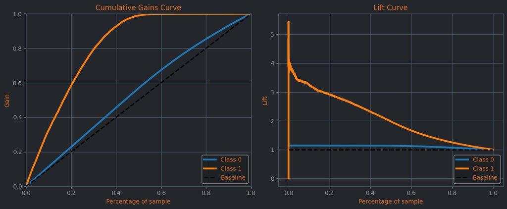

|  | model | precision@15244 | recall@15244 | f1@15244 | ndcg@15244 |
| --- | --- | --- | --- | --- | --- |
| 0 | xgb_final | 0.357166 | 0.582852 | 0.442917 | 0.558331 |

```python
xgb_y_test_proba = xgb_model_final.predict_proba(X_test)
xgb_metrics_test = get_metrics_at_k(X_test, y_test, xgb_y_test_proba, 'xgb_final', k=15244)

fig, axes = plt.subplots(1, 2, figsize=(12, 5))
skplt.metrics.plot_cumulative_gain(y_test, xgb_y_test_proba, ax=axes[0])
skplt.metrics.plot_lift_curve(y_test, xgb_y_test_proba, ax=axes[1])

axes[0].set_title("Cumulative Gains Curve")
axes[1].set_title("Lift Curve")

plt.tight_layout()
plt.show()

base_total = 76220
pct_contato = 0.20
clientes_contatados = int(base_total * pct_contato)

custo_por_contato = 10
lucro_por_venda = 400
taxa_base = 0.15

precision_modelo = xgb_metrics_test["precision@15244"].iloc[0] if "precision@15244" in xgb_metrics_test else 0.304  # valor

vendas_sem_modelo = clientes_contatados * taxa_base
lucro_sem_modelo = vendas_sem_modelo * lucro_por_venda
custo_sem_modelo = clientes_contatados * custo_por_contato
lucro_liquido_sem_modelo = lucro_sem_modelo - custo_sem_modelo

vendas_com_modelo = clientes_contatados * precision_modelo
lucro_com_modelo = vendas_com_modelo * lucro_por_venda
custo_com_modelo = clientes_contatados * custo_por_contato
lucro_liquido_com_modelo = lucro_com_modelo - custo_com_modelo

ganho_total = lucro_liquido_com_modelo - lucro_liquido_sem_modelo
roi = ganho_total / lucro_liquido_sem_modelo * 100

df_financeiro = pd.DataFrame({
    'Indicador': [
        'Lucro líquido sem modelo',
        'Lucro líquido com modelo',
        'Ganho adicional',
        'ROI vs aleatório (%)'
    ],
    'Valor': [
        round(lucro_liquido_sem_modelo, 2),
        round(lucro_liquido_com_modelo, 2),
        round(ganho_total, 2),
        round(roi, 2)
    ]
})

xgb_metrics_test
```

```python
df_financeiro
```

|  | Indicador | Valor |
| --- | --- | --- |
| 0 | Lucro líquido sem modelo | 762200.00 |
| 1 | Lucro líquido com modelo | 2025417.13 |
| 2 | Ganho adicional | 1263217.13 |
| 3 | ROI vs aleatório (%) | 165.73 |

**Resultados Financeiros**

**Cenário de Negócio (fictício, porém plausível)**

- Base total de clientes: **76.220 pessoas**
- O modelo ranqueia todos pela **probabilidade de comprar seguro veicular**
- A empresa decide contatar os **20% mais propensos** → **15.244 clientes**

**Premissas de custo e retorno**

[output not shown]

**Resultados do Modelo**

| Métrica | Valor | Interpretação |
| --- | --- | --- |
| **Precision@20%** | **0.357** | 35,7% dos contatados realmente compram |
| **Recall@20%** | **0.583** | Capta 58,3% de todos os compradores da base |
| **F1@20%** | **0.443** | Bom equilíbrio entre precisão e cobertura |
| **NDCG@20%** | **0.558** | Excelente ordenação: os mais prováveis aparecem no topo |

**Resultados Financeiros**

| Indicador | Valor (R$) | Interpretação |
| --- | --- | --- |
| **Lucro líquido sem modelo** | **762.200,00** | Resultado da campanha com contato aleatório |
| **Lucro líquido com modelo** | **2.025.417,13** | Resultado aplicando o modelo de propensão |
| **Ganho adicional** | **1.263.217,13** | Lucro extra gerado pelo modelo |
| **ROI vs aleatório** | **≈ 165,73%** | O modelo gera 2,65× mais retorno que a estratégia aleatória |

**Resumo Executivo**

> “Ao aplicar o modelo de propensão, aumentamos o lucro líquido da campanha de **R$ 762 mil para R$ 2,02 milhões**, utilizando o mesmo orçamento de contato. Isso representa um **ganho adicional de R$ 1,26 milhão** e um **ROI de 165,7%** em relação ao contato aleatório. Ou seja, o modelo permite **focar o esforço comercial nos clientes com maior probabilidade de conversão**, multiplicando significativamente o retorno da campanha.”

**Conclusão**

- O modelo **transforma um processo operacional em uma alavanca de lucro**, orientando os contatos para quem realmente tem probabilidade de comprar.
- Mesmo com um **Precision de ~35%**, o impacto financeiro é enorme graças à priorização correta.
- O retorno cresce para **2,65×** o resultado da estratégia sem modelo.
- Esse tipo de abordagem muda a campanha de *volume* para *inteligência*, reduzindo desperdício e aumentando a conversão.

## 14. Predição Final

```python
df_test = pd.read_csv('../data/test.csv')
```

```python
df_test.columns = snake_case(df_test.columns)
df_test['vehicle__damage'] = df_test['vehicle__damage'].map({'Yes': 1, 'No': 0}).astype(int)
df_test['vehicle_age_num'] = df_test['vehicle__age'].map({'< 1 Year': 0, '1-2 Year': 1, '> 2 Years': 2})
df_test = df_test.drop(columns=['vehicle__age'])
df_test['vehicle_risk'] = df_test['vehicle_age_num'] + df_test['vehicle__damage']
df_test['premium_per_vintage'] = df_test['annual__premium'] / df_test['vintage']
df_test['premium_per_age'] = df_test['annual__premium'] / df_test['age']
df_test['premium_per_risk'] = df_test['annual__premium'] / (df_test['vehicle_risk'] + 1e-5)
df_test['age_x_premium'] = df_test['age'] * df_test['annual__premium']
df_test['age_x_vehicle_age_num'] = df_test['age'] * df_test['vehicle_age_num']
df_test['damage_x_age_vehicle'] = df_test['vehicle__damage'] * df_test['vehicle_age_num']
df_test['age_x_vintage'] = df_test['age'] * df_test['vintage']
df_test['age_bucket'] = pd.cut(df_test['age'], bins=[18, 30, 40, 50, 60, 100], labels=[0, 1, 2, 3, 4])
df_test['age_x_bucket'] = df_test['age'] * df_test['age_bucket'].astype(int)
df_test['premium_bucket'] = pd.qcut(df_test['annual__premium'], q=5, labels=False)
df_test['vintage_per_age'] = df_test['vintage'] / df_test['age']
df_test['vintage_per_year'] = df_test['vintage'] / 12
df_test['age_squared'] = df_test['age'] ** 2
df_test['age_cubed'] = df_test['age'] ** 3
region_counts = df_test['region__code'].value_counts(normalize=True)
df_test['region__popularity'] = df_test['region__code'].map(region_counts)
channel_counts = df_test['policy__sales__channel'].value_counts(normalize=True)
df_test['channel_popularity'] = df_test['policy__sales__channel'].map(channel_counts)
df_test['region__avg_premium'] = df_test['region__code'].map(
    df_test.groupby('region__code')['annual__premium'].mean()
)
df_test['region_conversion_rate'] = df_test['region__code'].map(conversion_by_region)
df_test['policy__channel__avg_premium'] = df_test['policy__sales__channel'].map(
    df_test.groupby('policy__sales__channel')['annual__premium'].mean()
)
df_test['premium_minus_region_avg'] = df_test['annual__premium'] - df_test['region__avg_premium']
df_test['insurance_need_score'] = (
    (df_test['previously__insured'] == 0).astype(int) * 2 +
    df_test['vehicle_risk'] +
    df_test['vehicle__damage']
)
avg_premium_by_risk = df_test.groupby('vehicle_risk')['annual__premium'].mean()
df_test['premium_diff_risk'] = df_test['annual__premium'] - df_test['vehicle_risk'].map(avg_premium_by_risk)
df_test['channel_x_previously'] = df_test['policy__sales__channel'] * df_test['previously__insured']
df_test['channel_x_risk'] = df_test['policy__sales__channel'] * df_test['vehicle_risk']
df_test['is_new_customer'] = (df_test['vintage'] < df_test['vintage'].median()).astype(int)
df_test['avg_premium_same_age'] = df_test.groupby('age')['annual__premium'].transform('mean')
df_test['premium_rel_age'] = df_test['annual__premium'] / df_test['avg_premium_same_age']
df_test['premium_age_percentile'] = df_test.groupby('age')['annual__premium'].rank(pct=True)
df_test['risk_alignment'] = df_test['insurance_need_score'] * df_test['vehicle_risk']
```

```python
log_transform_cols = [
    'age_x_premium',
    'premium_per_risk',
    'premium_per_age',
    'premium_per_vintage'
]

for col in log_transform_cols:
    df_test[col + '_log'] = np.log1p(df_test[col])
    df_test.drop(columns=col, inplace=True)
```

```python
cols_to_scale_standard = [
    'age',
    'vintage',
    'vintage_per_age',
    'region__popularity',
    'channel_x_risk',
    'channel_x_previously',
    'insurance_need_score',
    'channel_popularity',
    'age_x_bucket',
    'age_x_vintage',
    'vehicle_age_num',
    'premium_rel_age',
    'damage_x_age_vehicle',
    'age_x_vehicle_age_num',
    'risk_alignment',
    'vehicle_risk',
    'annual__premium',
    'premium_per_age_log',
    'premium_per_vintage_log',
    'age_x_premium_log',
    'premium_bucket',
    'region__avg_premium',
    'policy__channel__avg_premium',
    'premium_diff_risk',
    'premium_per_risk_log',
    'premium_minus_region_avg',
    'age_cubed',
    'vintage_per_year',
    'avg_premium_same_age',
    'age_squared'
]


df_test[cols_to_scale_standard] = standard_scaler.transform(df_test[cols_to_scale_standard])
```

```python
cols_to_scale_minmax = [
    'region_conversion_rate',
    'premium_age_percentile',
]

df_test[cols_to_scale_minmax] = minmax_scaler.transform(df_test[cols_to_scale_minmax])
```

```python
df_test['gender'] = df_test['gender'].map({'Male': 1, 'Female': 0})

age_bucket_encoded = ohe_age.transform(df_test[['age_bucket']])
age_bucket_columns = [f'age_bucket_{cat}' for cat in ohe_age.categories_[0]]
df_test[age_bucket_columns] = age_bucket_encoded
df_test = df_test.drop('age_bucket', axis=1)

premium_bucket_encoded = ohe_premium.transform(df_test[['premium_bucket']])
premium_bucket_columns = [f'premium_bucket_{cat}' for cat in ohe_premium.categories_[0]]
df_test[premium_bucket_columns] = premium_bucket_encoded
df_test = df_test.drop('premium_bucket', axis=1)

df_test['region__code'] = df_test['region__code'].map(region_code_target_mean)

df_test['policy__sales__channel'] = df_test['policy__sales__channel'].map(policy_sales_freq)
```

```python
df_test = df_test[['id'] + list(X.columns)]
y_proba_test = xgb_model_final.predict_proba(df_test.drop('id', axis=1))
df_test['score'] = y_proba_test[:, 1]
df_test = df_test.sort_values(by='score', ascending=False).reset_index(drop=True)
df_test = df_test[['id', 'score']]
```

```python
df_test['score'] = y_proba_test[:, 1]
df_test = df_test.sort_values(by='score', ascending=False).reset_index(drop=True)
df_test = df_test[['id', 'score']]
```

```python
df_test.to_csv('../data/test_final.csv', index=False)
```

```python
df_test.head().T
```

|  | 0 | 1 | 2 | 3 | 4 |
| --- | --- | --- | --- | --- | --- |
| id | 390147.000000 | 463439.000000 | 504617.000000 | 458736.000000 | 463408.000000 |
| score | 0.550305 | 0.536014 | 0.534712 | 0.533745 | 0.531486 |

## 15. Conclusão

Os resultados mostram que o modelo de propensão apresenta **excelente desempenho preditivo** e impacto financeiro significativo para a campanha de *cross-sell*. No threshold otimizado para maximizar o F1-score (**0.2312**), o modelo atinge um **F1 = 0.4609**, equilibrando precisão e recall para a classe minoritária.

**Classification Report**

| Classe | Precision | Recall | F1-score | Suporte |
| --- | --- | --- | --- | --- |
| **0** | 0.96 | 0.79 | 0.86 | 66.880 |
| **1** | 0.33 | 0.76 | 0.46 | 9.342 |
| **Accuracy** | — | — | **0.78** | 76.222 |
| **Macro Avg** | 0.64 | 0.77 | 0.66 | 76.222 |
| **Weighted Avg** | 0.88 | 0.78 | 0.81 | 76.222 |

**Matriz de Confusão**

|  | Predito 0 | Predito 1 |
| --- | --- | --- |
| **Classe 0 (real)** | 52.555 | 14.325 |
| **Classe 1 (real)** | 2.254 | 7.088 |

**Métricas Globais**

| Métrica | Valor |
| --- | --- |
| **AUC-ROC** | 0.8583 |
| **AUC-PR** | 0.3689 |

Esses resultados são especialmente relevantes em um problema **desbalanceado**, no qual a classe positiva representa uma fração pequena, mas altamente valiosa para o negócio. O modelo demonstra forte capacidade de **recuperar a maioria dos compradores** (recall de 76% na classe positiva), mesmo com precisão moderada, uma troca adequada em cenários onde cada cliente corretamente identificado gera alto retorno.

Quando aplicado ao ranking dos **20% mais propensos**, o desempenho se traduz diretamente em ganho comercial:

**Resultados Financeiros**

| Indicador | Valor (R$) | Interpretação |
| --- | --- | --- |
| **Lucro líquido sem modelo** | 762.200,00 | Contato aleatório |
| **Lucro líquido com modelo** | 2.025.417,13 | Aplicando ranqueamento por propensão |
| **Ganho adicional** | 1.263.217,13 | Lucro extra devido ao modelo |
| **ROI vs aleatório** | 165,73% | 2,65× mais retorno |

> “Ao aplicar o modelo de propensão, aumentamos o lucro líquido da campanha de **R$ 762 mil para R$ 2,02 milhões**, mantendo o mesmo número de contatos. Esse resultado representa um **ganho adicional de R$ 1,26 milhão** e um **ROI de 165,7%** frente à estratégia aleatória. O modelo permite **focar o esforço comercial nos clientes com maior probabilidade de compra**, multiplicando o retorno sem aumentar custos.”

**Ou Seja**

- O modelo **transforma a operação em uma estratégia data-driven**, priorizando clientes com maior probabilidade de conversão.
- Mesmo com **Precision moderada (0.33) para a classe positiva**, o alto **recall (0.76)** garante que a maioria dos potenciais compradores é identificada.
- O impacto financeiro é expressivo: **2,65× mais retorno** sem ampliar o volume de contatos.
- A campanha deixa de ser baseada em volume e passa a ser guiada por **inteligência preditiva**, reduzindo desperdícios e aumentando substancialmente a conversão.